# DSP4SH v6 - Indicator Analysis

Katy Dynarski

2024-4-12

# Project Background Information

## Maps and tables about DSP4SH projects

| project | soils |
| --- | --- |
| KansasState | Keith |
| NCState | Cecil |
| WashingtonState | Palouse |
| UnivOfMinnesota | Marquis, Readlyn, Kenyon |
| Illinois | Drummer |
| UConn | Woodbridge, Canton |
| TexasA&MPt-1 | Amarillo |
| TexasA&MPt-2 | Pullman |
| OregonState | Jory, Woodburn |
| UTRGV | Hidalgo |

Make map:

```
## Scale on map varies by more than 10%, scale bar may be inaccurate
```

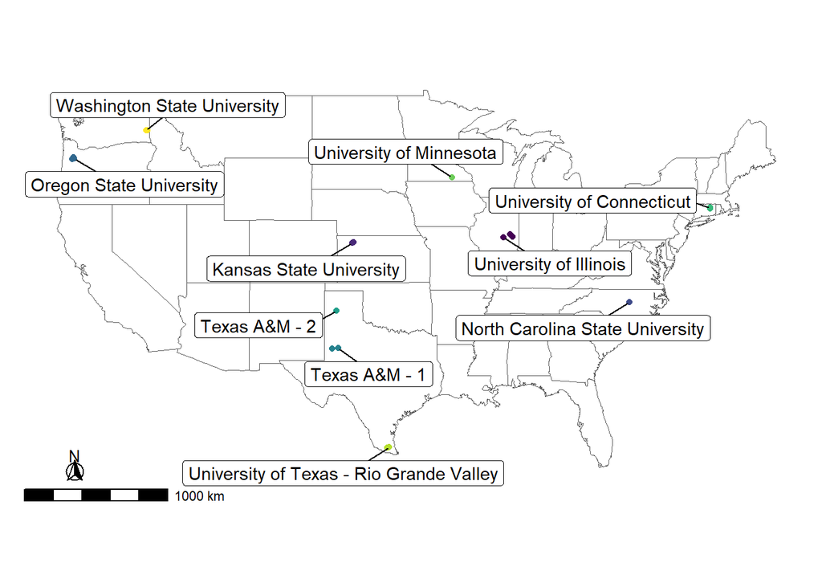

```
## Scale on map varies by more than 10%, scale bar may be inaccurate
```

Generate overview table of project information:

| project | soils | label | description | mat | map |
| --- | --- | --- | --- | --- | --- |
| Illinois | Drummer | BAU | Conventional and organic corn-soybean rotation | 11.4 | 999 |
| Illinois | Drummer | Ref | Forest restored in 1990 | 11.4 | 999 |
| Illinois | Drummer | SHM | No-till corn-soybean rotation | 11.4 | 999 |
| KansasState | Keith | BAU | Diverse crops with conventional tillage | 11.1 | 537 |
| KansasState | Keith | Ref | Native rangeland | 11.1 | 537 |
| KansasState | Keith | SHM | No-till diverse crops and cover cropping | 11.1 | 537 |
| NCState | Cecil | BAU | Wheat and corn with conventional tillage | 15.7 | 1,223 |
| NCState | Cecil | Ref | Forest | 15.7 | 1,223 |
| NCState | Cecil | SHM | Hayed perennial grass | 15.7 | 1,223 |
| OregonState | Jory, Woodburn | BAU | Ryegrass and Christmas tree with tillage | 11.5 | 1,198 |
| OregonState | Jory, Woodburn | Ref | Timber forest and hazelnut orchard | 11.5 | 1,198 |
| OregonState | Jory, Woodburn | SHM | No-till grass and vineyard | 11.5 | 1,198 |
| TexasA&MPt-1 | Amarillo | BAU | Cropping with conventional tillage | 16.4 | 439 |
| TexasA&MPt-1 | Amarillo | Ref | Native rangeland | 16.4 | 439 |
| TexasA&MPt-1 | Amarillo | SHM | No-till rye and mixed crops | 16.4 | 439 |
| TexasA&MPt-2 | Pullman | BAU | Wheat and sorghum with conventional tillage | 13.7 | 469 |
| TexasA&MPt-2 | Pullman | Ref | Native perennial forage | 13.7 | 469 |
| TexasA&MPt-2 | Pullman | SHM | No-till wheat and sorghum | 13.7 | 469 |
| UConn | Woodbridge, Canton | BAU | Corn with conventional tillage | 9.6 | 1,247 |
| UConn | Woodbridge, Canton | Ref | Forest | 9.6 | 1,247 |
| UConn | Woodbridge, Canton | SHM | No-till corn and hay | 9.6 | 1,247 |
| UTRGV | Hidalgo | BAU | Diverse crops with conventional tillage | 23.7 | 644 |
| UTRGV | Hidalgo | Ref | Native forest | 23.7 | 644 |
| UnivOfMinnesota | Marquis, Readlyn, Kenyon | BAU | Soybean with conventional tillage | 6.9 | 909 |
| UnivOfMinnesota | Marquis, Readlyn, Kenyon | Ref | Native rangeland | 6.9 | 909 |
| UnivOfMinnesota | Marquis, Readlyn, Kenyon | SHM | No-till soybean | 6.9 | 909 |
| WashingtonState | Palouse | BAU | Cropping with conventional tillage | 9.0 | 527 |
| WashingtonState | Palouse | Ref | Perennial grassland | 9.0 | 527 |
| WashingtonState | Palouse | SHM | No-till cropping | 9.0 | 527 |

## Environmental data tables

Table of range in environmental conditions - this is not for a table but is referenced directly in the text:

| name | value |
| --- | --- |
| lat_range | 26.31-46.79 |
| long_range | -123.42--72.19 |
| mat_range | 6.84-23.89 |
| map_range | 354.97-1476.5 |

Range in indicator values across all sites:

| indicator | value_min | value_max |
| --- | --- | --- |
| ace | 0.03 | 48.09 |
| acid_phosphatase | 2.30 | 1,330.41 |
| alkaline_phosphatase | -1.47 | 37,791.32 |
| arylsulfatase | -2.08 | 1,034.16 |
| bglucosaminidase | -0.17 | 1,740.11 |
| bglucosidase | 4.91 | 952.71 |
| bulk_density | 0.58 | 2.38 |
| kssl_wsa | 0.30 | 94.45 |
| pox_c | 60.62 | 1,082.00 |
| soc_pct | 0.15 | 12.66 |
| soil_respiration | 0.07 | 356.55 |
| yoder_agg_stab_mwd | 0.06 | 48.57 |

Range in indicator values in reference sites only:

| indicator | value_min | value_max |
| --- | --- | --- |
| ace | 0.08 | 48.09 |
| acid_phosphatase | 8.22 | 1,053.14 |
| alkaline_phosphatase | -1.47 | 1,300.02 |
| arylsulfatase | 2.33 | 1,034.16 |
| bglucosaminidase | 1.35 | 444.73 |
| bglucosidase | 14.34 | 468.69 |
| bulk_density | 0.68 | 2.38 |
| kssl_wsa | 0.30 | 90.96 |
| pox_c | 155.43 | 1,082.00 |
| soc_pct | 0.33 | 12.66 |
| soil_respiration | 0.34 | 339.40 |
| yoder_agg_stab_mwd | 0.06 | 47.50 |

# Analysis of soil health indicator variability across DSP4SH projects

For most of the analyses here, I will be looking at indicator values in the 0-10 cm depth increment only (0-5 cm and 5-10 cm values were averaged to get 0-10 cm values).

## Boxplots of indicator values across all projects

Start by making boxplots of indicator values across treatments in all projects:

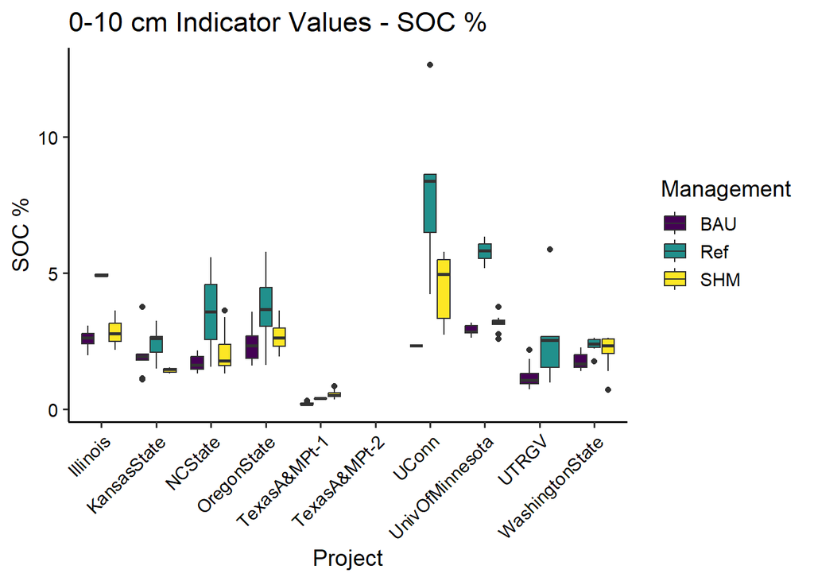

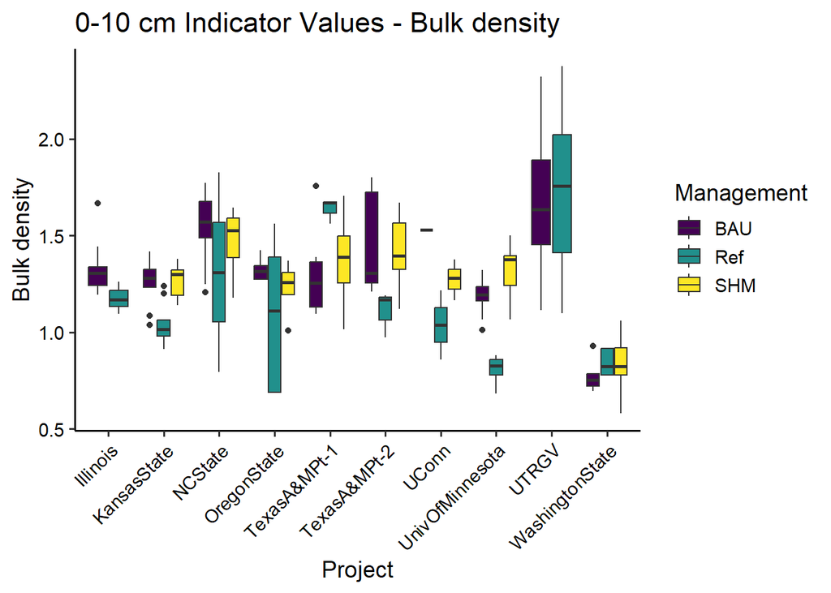

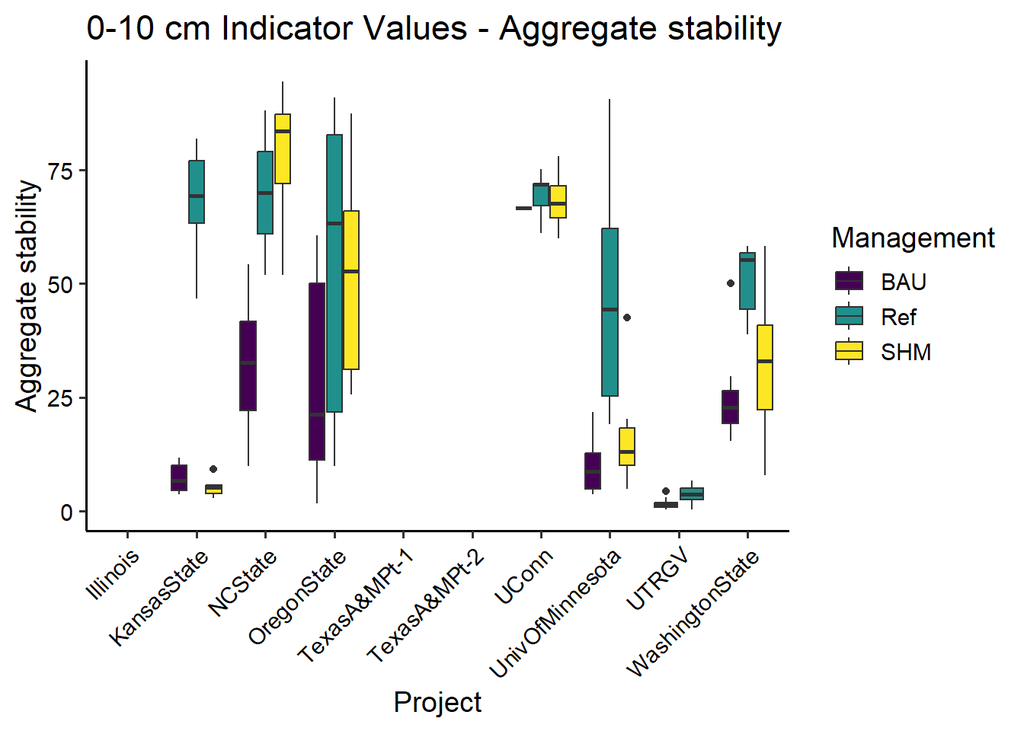

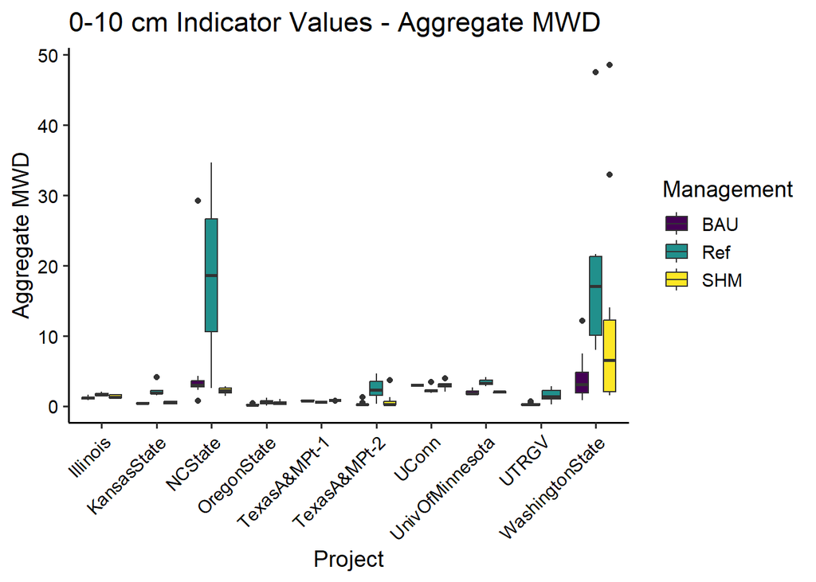

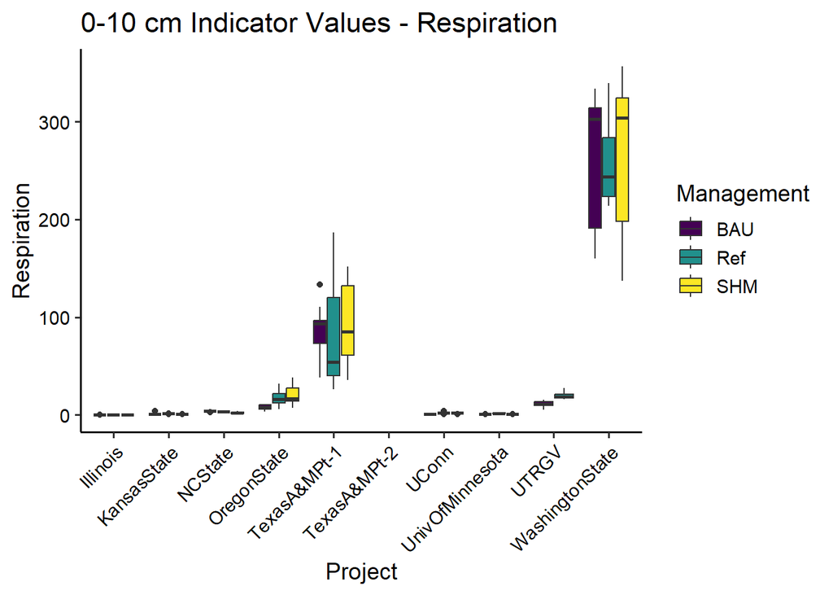

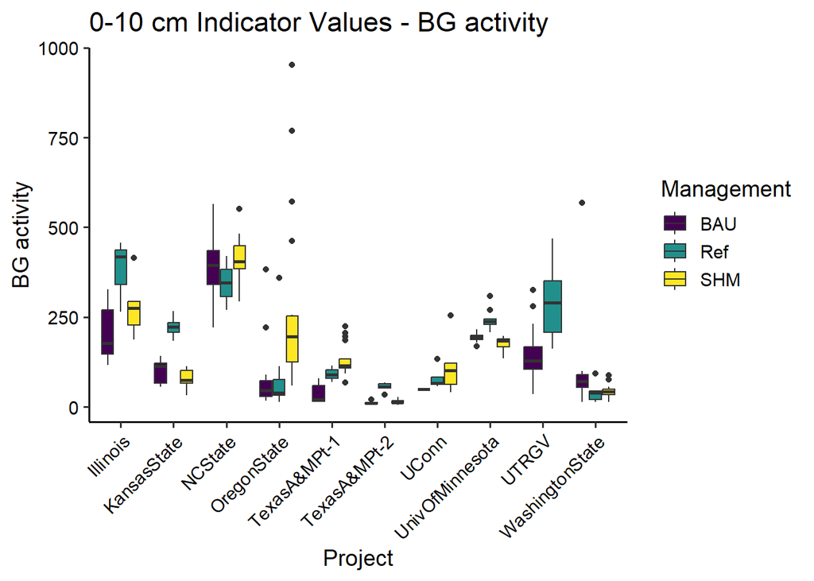

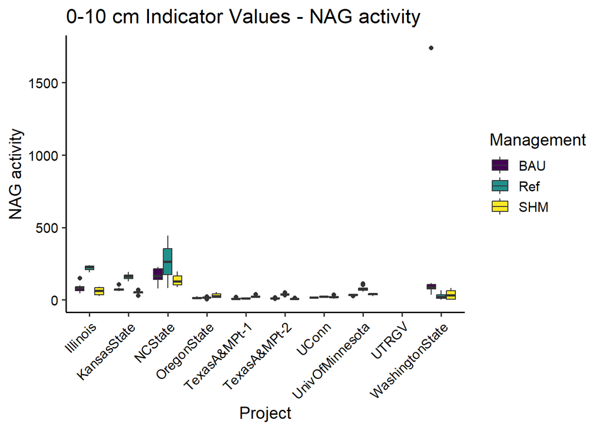

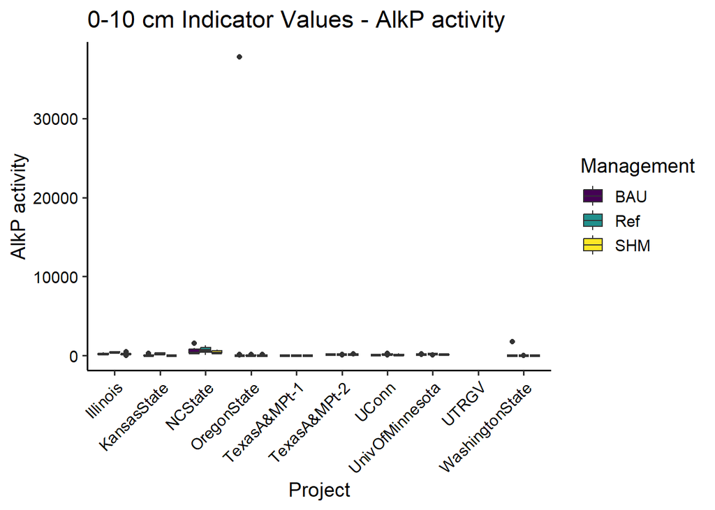

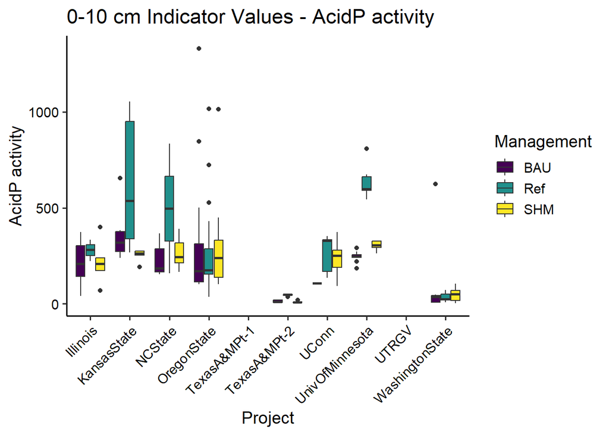

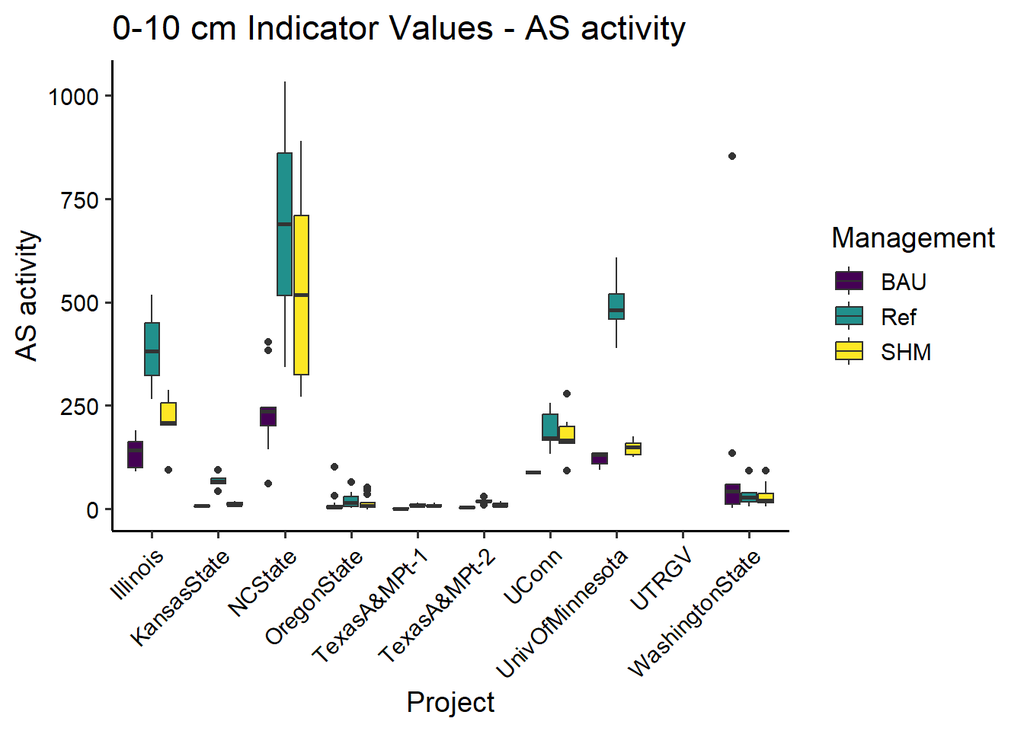

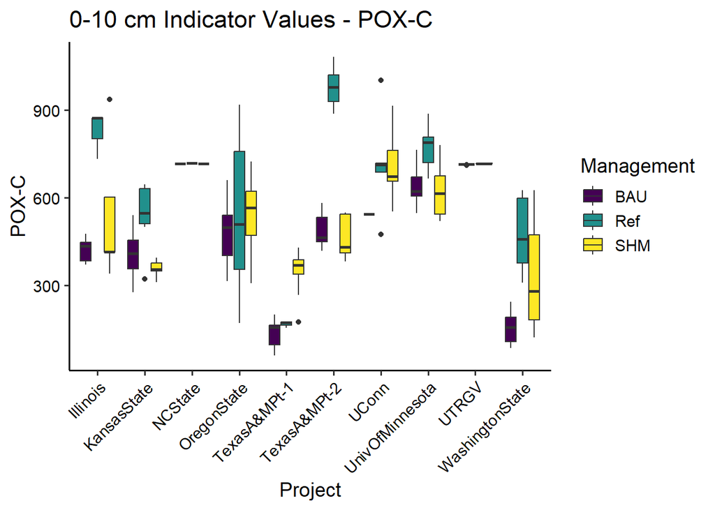

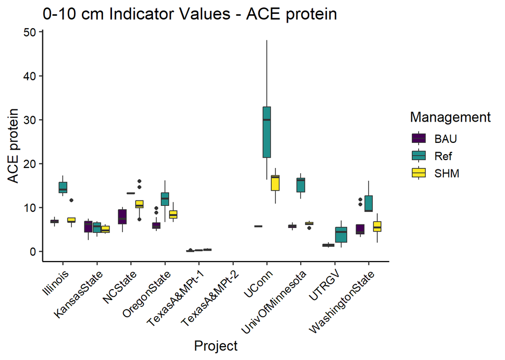

Alternate version where each plot shows one project:

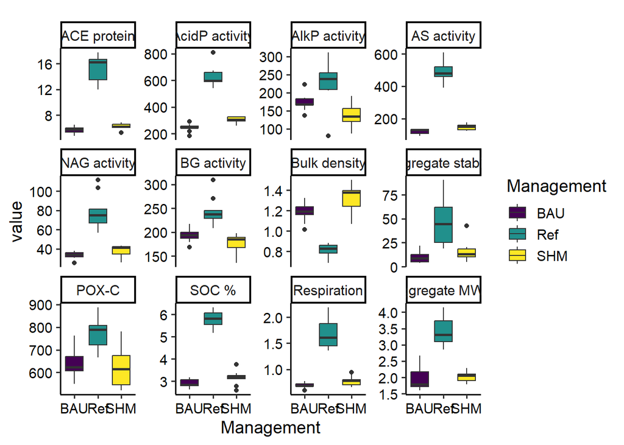

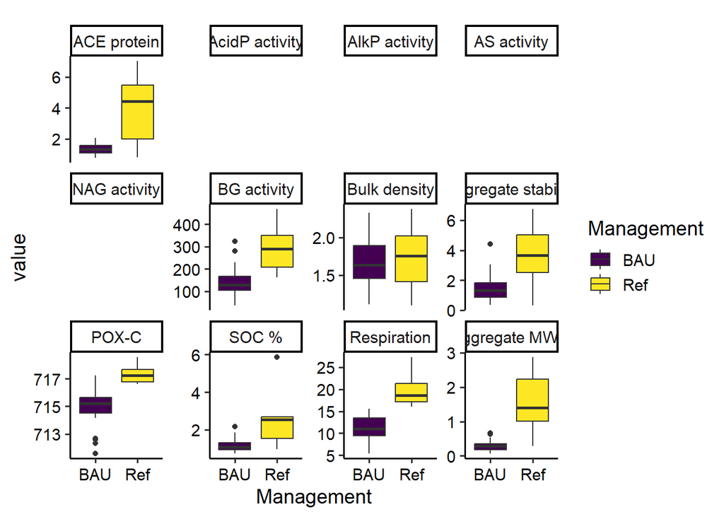

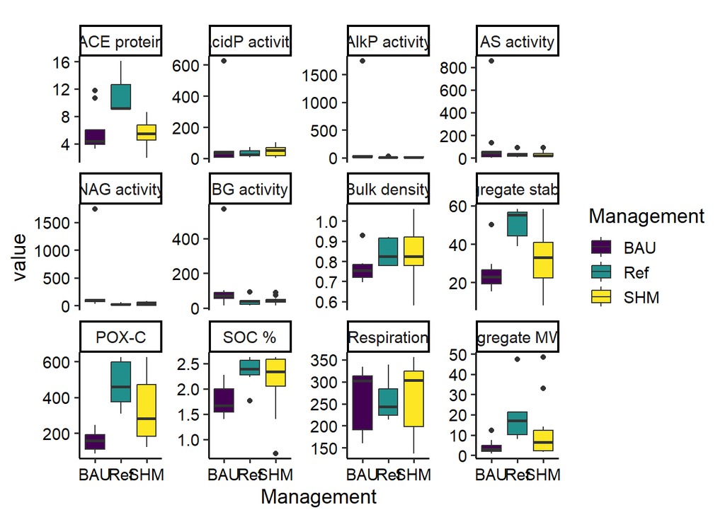

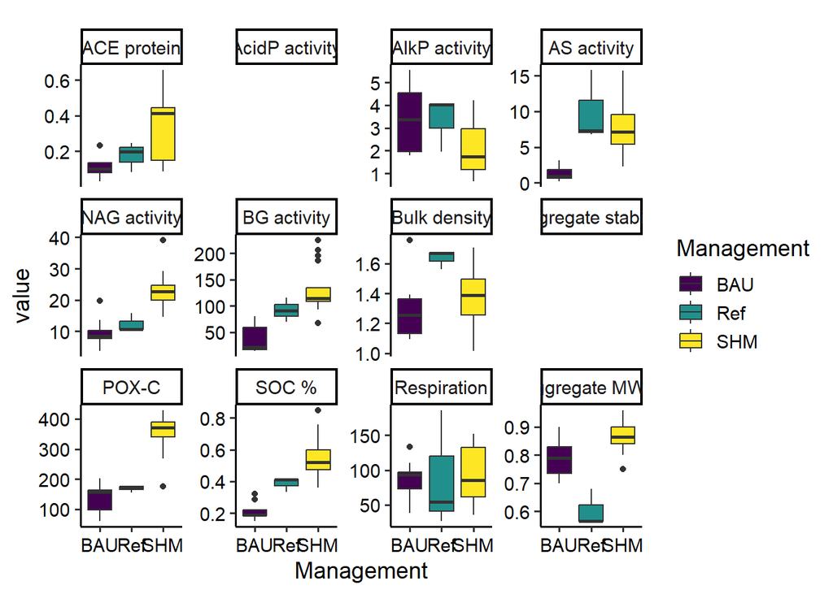

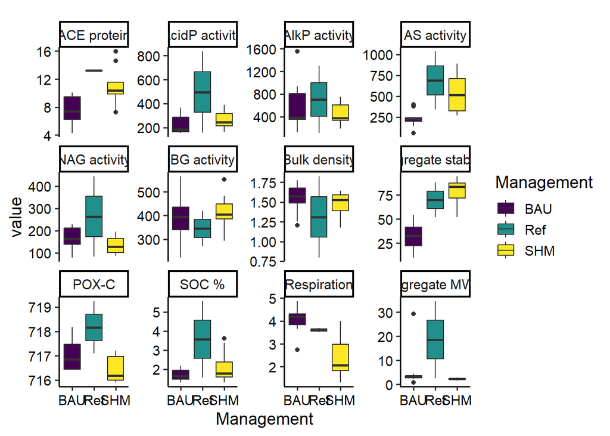

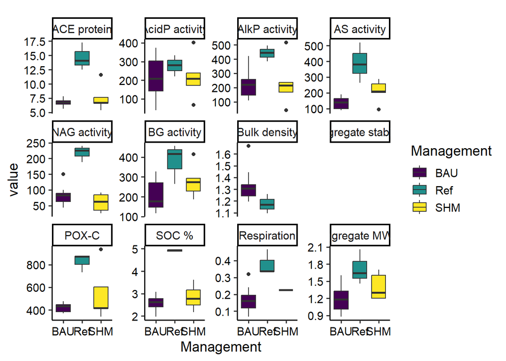

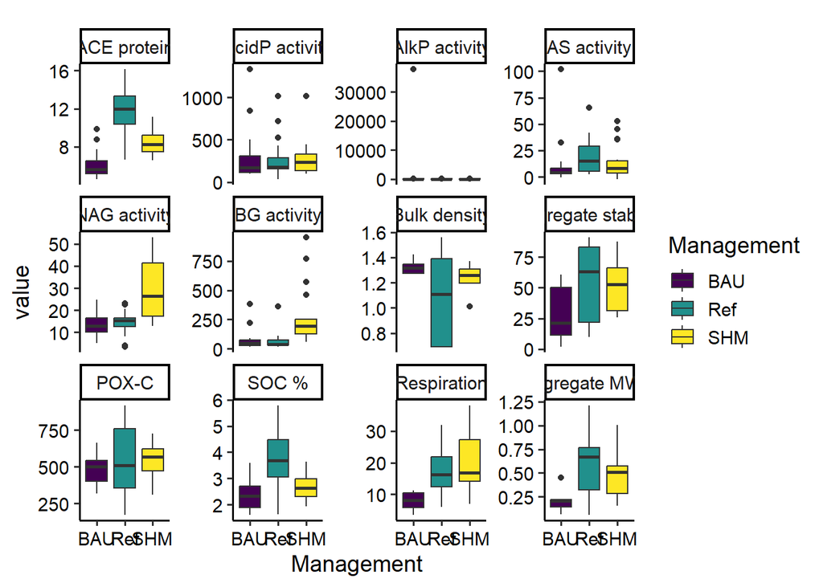

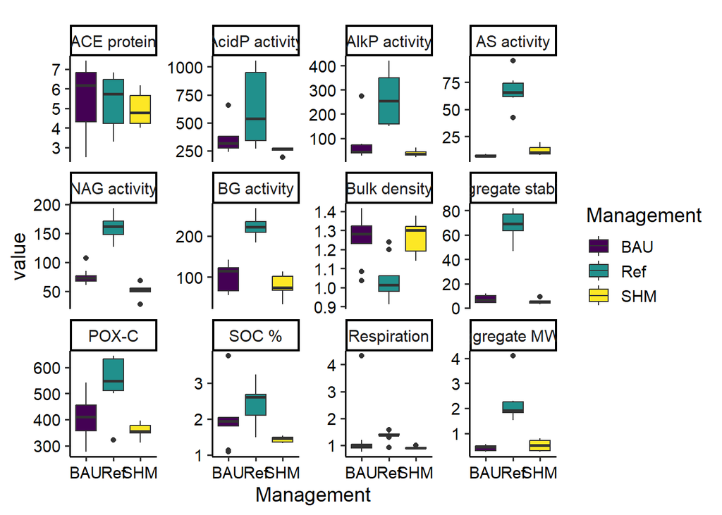

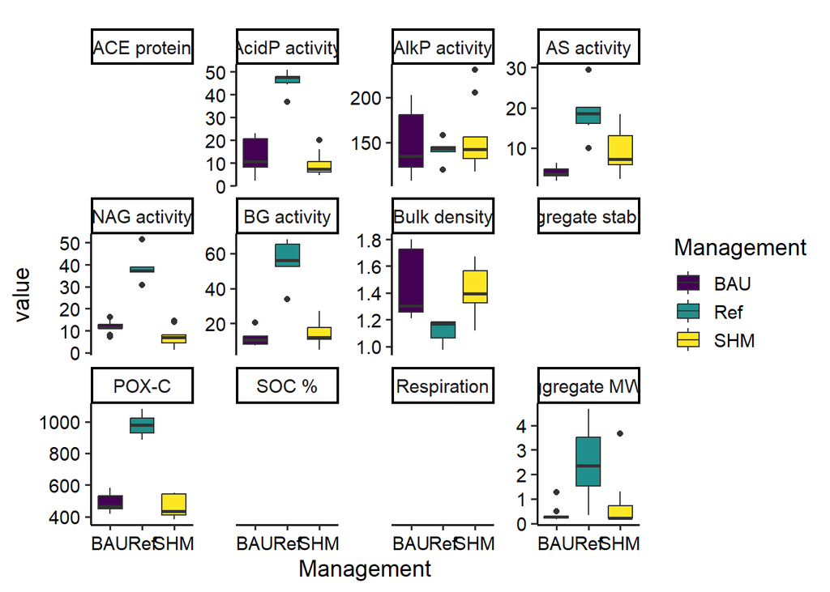

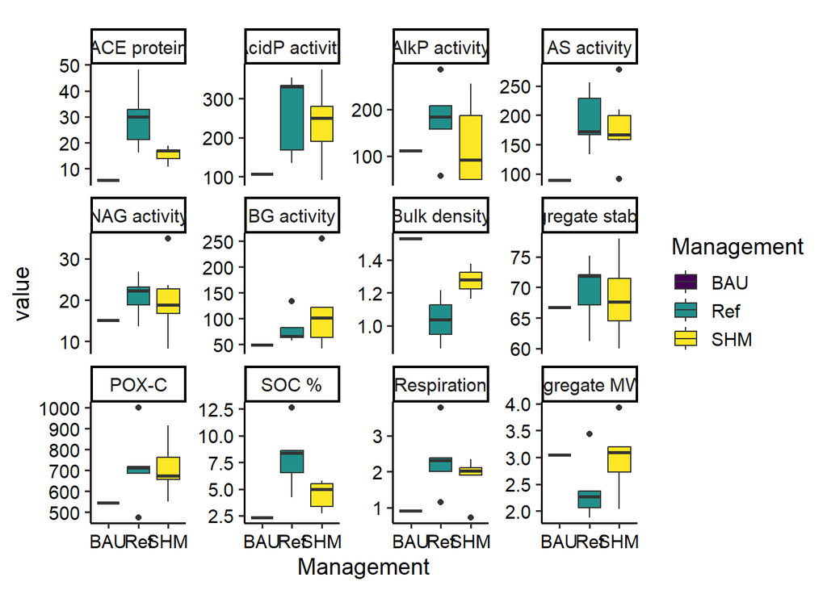

Initial takeaways from figures:

- It’s difficult to compare indicator values between projects because there is so much variability between projects in terms of response to management and absolute value of the data.
- Data tend to be all over the place - there’s no obvious pattern of indicator values always being higher in a particular treatment. Overall, indicator values are most frequently higher in Ref management but even that is not consistent across indicators/between projects.
- KSSL WSA appears to be one of the more sensitive to management indicators - most consistently higher in Ref systems
- POX-C, SOC also tend to be higher in Ref systems
- Values of soil respiration are really different between projects
- Most indicator values tend to be higher under Ref management in Illinois, Kansas State, NC State, Minnesota projects
- SHM seems to influence several indicators (ACE, POX-C, Yoder MWD, SOC%) in Texas A&M pt 1 project (and values in SHM are actually higher than in Ref)

Make a version of these figures that shows two frequently measured indicators and how their response to management varies across a precipitation gradient:

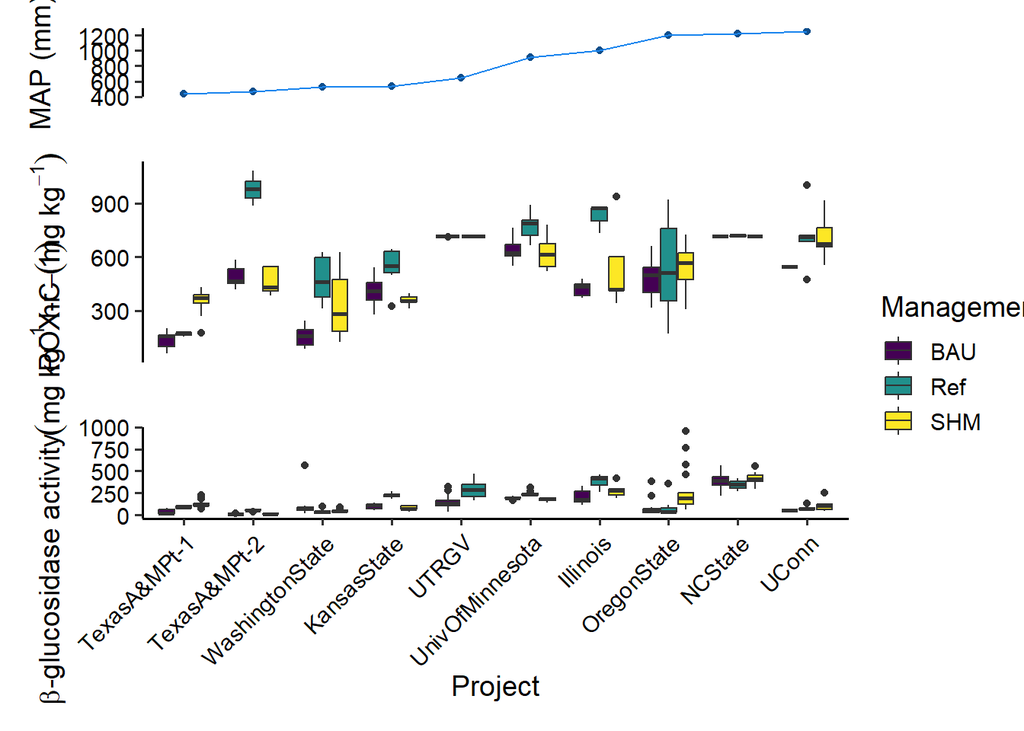

## Summary tables of indicator values

Mean indicator values in Reference, SHM, and BAU systems:

| project | label | summary_ace | summary_acid_phosphatase | summary_alkaline_phosphatase | summary_arylsulfatase | summary_bglucosaminidase | summary_bglucosidase | summary_bulk_density | summary_pox_c | summary_soc_pct | summary_soil_respiration | summary_yoder_agg_stab_mwd | summary_kssl_wsa | value_cv_ace | value_cv_acid_phosphatase | value_cv_alkaline_phosphatase | value_cv_arylsulfatase | value_cv_bglucosaminidase | value_cv_bglucosidase | value_cv_bulk_density | value_cv_pox_c | value_cv_soc_pct | value_cv_soil_respiration | value_cv_yoder_agg_stab_mwd | value_cv_kssl_wsa |
| --- | --- | --- | --- | --- | --- | --- | --- | --- | --- | --- | --- | --- | --- | --- | --- | --- | --- | --- | --- | --- | --- | --- | --- | --- | --- |
| Illinois | BAU | 6.75_0.59 | 213.23_114.23 | 220.4_89.15 | 133.94_34.94 | 81.28_28.26 | 202.04_74.21 | 1.33_0.13 | 424.38_37.7 | 2.59_0.33 | 0.17_0.07 | 1.2_0.25 |  | 8.71 | 53.57 | 40.45 | 26.08 | 34.76 | 36.73 | 9.61 | 8.88 | 12.64 | 43.44 | 20.69 |  |
| Illinois | Ref | 14.61_2.4 | 278.68_55.73 | 440.63_55.37 | 388.48_126.77 | 218.15_26.79 | 379.83_101.26 | 1.18_0.08 | 826.53_81.21 | 4.92_0.08 | 0.38_0.08 | 1.72_0.31 |  | 16.42 | 20.00 | 12.57 | 32.63 | 12.28 | 26.66 | 7.05 | 9.83 | 1.60 | 19.96 | 17.90 |  |
| Illinois | SHM | 7.6_2.37 | 217.55_120.87 | 236.01_173.15 | 209.87_73.32 | 59.72_29 | 279.74_86.09 |  | 542.1_240.32 | 2.85_0.57 |  | 1.4_0.23 |  | 31.13 | 55.56 | 73.36 | 34.94 | 48.57 | 30.78 |  | 44.33 | 19.88 |  | 16.75 |  |
| KansasState | BAU | 5.51_1.81 | 345.3_127.54 | 72.14_76.99 | 6.92_1 | 75.82_13.9 | 100.66_30.69 | 1.25_0.12 | 407.16_80.15 | 1.96_0.77 | 1.33_1.13 | 0.43_0.11 | 7.46_3.09 | 32.91 | 36.94 | 106.72 | 14.48 | 18.33 | 30.48 | 9.75 | 19.68 | 39.11 | 85.04 | 26.50 | 41.40 |
| KansasState | Ref | 5.29_1.33 | 638.13_321.41 | 260.23_103.04 | 67.78_17.41 | 160.04_19.38 | 222.04_25.55 | 1.04_0.11 | 546.85_101.24 | 2.46_0.56 | 1.36_0.18 | 2.15_0.78 | 67.35_11.8 | 25.19 | 50.37 | 39.60 | 25.69 | 12.11 | 11.51 | 10.64 | 18.51 | 22.62 | 13.52 | 36.24 | 17.53 |
| KansasState | SHM | 4.95_0.92 | 253.89_31.52 | 38.37_13.73 | 12.31_6.31 | 50.41_13.36 | 78_29.65 | 1.27_0.1 | 358.13_29.48 | 1.44_0.09 | 0.91_0.04 | 0.52_0.24 | 5.31_2.23 | 18.51 | 12.41 | 35.79 | 51.30 | 26.50 | 38.01 | 7.51 | 8.23 | 6.35 | 4.87 | 45.21 | 41.96 |
| NCState | BAU | 7.72_2.03 | 228.59_77.8 | 587.42_442.52 | 238.09_105.95 | 170_52.88 | 382.13_102.84 | 1.54_0.19 | 717.02_0.62 | 1.69_0.29 | 4.01_0.59 | 5.82_8.84 | 32.21_15.95 | 26.28 | 34.03 | 75.33 | 44.50 | 31.10 | 26.91 | 12.60 | 0.09 | 16.87 | 14.76 | 151.88 | 49.52 |
| NCState | Ref | 13.2_0.17 | 496.27_477.1 | 704.74_841.85 | 688.64_488.64 | 263.54_256.23 | 345.23_106.17 | 1.31_0.73 | 718.17_1.53 | 3.57_2.84 | 3.61_0.13 | 18.63_22.72 | 70.01_25.59 | 1.28 | 96.14 | 119.45 | 70.96 | 97.23 | 30.75 | 55.72 | 0.21 | 79.43 | 3.60 | 121.96 | 36.56 |
| NCState | SHM | 10.91_2.87 | 262.59_74.04 | 443.89_199.95 | 517.01_217.86 | 133.26_37.81 | 415.34_73.19 | 1.49_0.15 | 716.45_0.55 | 2.16_0.82 | 2.47_0.96 | 2.18_0.48 | 78.8_13.12 | 26.31 | 28.20 | 45.04 | 42.14 | 28.38 | 17.62 | 10.29 | 0.08 | 38.10 | 38.94 | 22.19 | 16.65 |
| OregonState | BAU | 6.11_1.4 | 298.02_321.09 | 2137.66_8898.03 | 11.9_23.61 | 13.32_5.2 | 74.32_90.3 | 1.32_0.05 | 484.66_97.85 | 2.35_0.61 | 8.06_2.64 | 0.21_0.13 | 29.08_21.29 | 22.84 | 107.74 | 416.25 | 198.45 | 39.02 | 121.50 | 4.03 | 20.19 | 25.90 | 32.72 | 62.33 | 73.21 |
| OregonState | Ref | 11.62_2.78 | 272.18_252.69 | 49.41_29.34 | 19.6_16.86 | 14.82_5.6 | 66.96_79.02 | 1.09_0.35 | 544.34_246.92 | 3.68_1.12 | 17.27_7.41 | 0.58_0.34 | 54.58_32.12 | 23.92 | 92.84 | 59.37 | 85.99 | 37.78 | 118.02 | 31.88 | 45.36 | 30.44 | 42.88 | 58.73 | 58.85 |
| OregonState | SHM | 8.4_1.3 | 276.14_213 | 39.92_42.18 | 14.34_16.45 | 29.18_13.63 | 276.84_251.52 | 1.23_0.12 | 547.92_119.04 | 2.72_0.51 | 19.83_8.81 | 0.48_0.25 | 52.5_21.24 | 15.53 | 77.14 | 105.67 | 114.76 | 46.72 | 90.85 | 9.46 | 21.73 | 18.85 | 44.44 | 52.00 | 40.45 |
| TexasA&MPt-1 | BAU | 0.11_0.06 |  | 3.36_1.48 | 1.33_0.99 | 9.59_4.65 | 34.95_25.56 | 1.29_0.2 | 138.22_53.52 | 0.21_0.05 | 85.83_30.07 | 0.79_0.07 |  | 49.79 |  | 43.87 | 74.11 | 48.44 | 73.14 | 15.56 | 38.72 | 25.67 | 35.04 | 8.51 |  |
| TexasA&MPt-1 | Ref | 0.17_0.08 |  | 3.35_1.21 | 9.97_5.02 | 12.29_3.04 | 91.71_23.09 | 1.64_0.06 | 169.08_11.96 | 0.38_0.04 | 89_85.55 | 0.6_0.07 |  | 47.62 |  | 36.23 | 50.32 | 24.71 | 25.17 | 3.98 | 7.07 | 11.25 | 96.12 | 11.00 |  |
| TexasA&MPt-1 | SHM | 0.35_0.18 |  | 2.2_1.19 | 7.54_3.51 | 22.71_5.63 | 131.33_42.97 | 1.36_0.19 | 357.45_60.08 | 0.55_0.12 | 93.61_39.36 | 0.86_0.05 |  | 51.16 |  | 53.84 | 46.51 | 24.78 | 32.72 | 13.82 | 16.81 | 21.35 | 42.05 | 5.86 |  |
| TexasA&MPt-2 | BAU |  | 12.6_7.55 | 150.14_37.12 | 3.72_1.43 | 11.74_2.95 | 11.35_3.93 | 1.46_0.26 | 483.94_55.63 |  |  | 0.37_0.35 |  |  | 59.92 | 24.72 | 38.57 | 25.14 | 34.59 | 17.56 | 11.49 |  |  | 94.26 |  |
| TexasA&MPt-2 | Ref |  | 45.78_4.85 | 141.14_12.58 | 18.75_6.41 | 38.77_6.9 | 55.57_12.57 | 1.12_0.09 | 978.75_72.15 |  |  | 2.48_1.59 |  |  | 10.58 | 8.92 | 34.17 | 17.80 | 22.63 | 8.31 | 7.37 |  |  | 64.00 |  |
| TexasA&MPt-2 | SHM |  | 9.5_5.24 | 155.15_38.54 | 9.37_5.69 | 7.11_4.54 | 14.2_6.94 | 1.43_0.18 | 460.72_68.77 |  |  | 0.82_1.13 |  |  | 55.10 | 24.84 | 60.72 | 63.93 | 48.84 | 12.57 | 14.93 |  |  | 138.04 |  |
| UConn | Ref | 29.69_12.24 | 264.1_103.25 | 178.6_82.13 | 191.4_49.87 | 20.93_4.98 | 80.48_31.01 | 1.04_0.25 | 719.22_187.69 | 8.08_3.11 | 2.32_0.95 | 2.4_0.61 | 69.49_5.47 | 41.21 | 39.09 | 45.99 | 26.06 | 23.78 | 38.53 | 24.19 | 26.10 | 38.48 | 41.09 | 25.22 | 7.87 |
| UConn | SHM | 15.6_3.09 | 237.36_96.85 | 123.62_89.13 | 178.05_61.86 | 20.15_8.83 | 113.03_76.82 | 1.27_0.08 | 709.55_126.17 | 4.48_1.37 | 1.85_0.57 | 3_0.63 | 68.22_6.43 | 19.83 | 40.80 | 72.10 | 34.74 | 43.82 | 67.96 | 6.20 | 17.78 | 30.53 | 30.98 | 21.03 | 9.43 |
| UTRGV | BAU | 1.33_0.34 |  |  |  |  | 144.69_67.24 | 1.68_0.33 | 714.96_1.36 | 1.18_0.36 | 11.21_2.82 | 0.3_0.15 | 1.48_0.96 | 25.62 |  |  |  |  | 46.47 | 19.74 | 0.19 | 30.44 | 25.15 | 51.73 | 64.97 |
| UTRGV | Ref | 3.94_2.46 |  |  |  |  | 293.81_115.26 | 1.73_0.47 | 717.35_0.75 | 2.64_1.75 | 19.89_4.24 | 1.56_0.96 | 3.66_2.28 | 62.36 |  |  |  |  | 39.23 | 27.36 | 0.10 | 66.22 | 21.31 | 61.73 | 62.19 |
| UnivOfMinnesota | BAU | 5.67_0.61 | 245.46_30.04 | 173.87_24.24 | 123.27_16.01 | 33.36_3.93 | 194.24_15.38 | 1.19_0.1 | 637.84_69.12 | 2.9_0.19 | 0.69_0.06 | 1.99_0.37 | 10.47_6.36 | 10.69 | 12.24 | 13.94 | 12.99 | 11.77 | 7.92 | 8.08 | 10.84 | 6.57 | 8.03 | 18.52 | 60.75 |
| UnivOfMinnesota | Ref | 15.28_1.99 | 634.21_78.79 | 225.99_62.89 | 485.52_63.64 | 78.89_18.31 | 243.62_29.96 | 0.81_0.06 | 777.96_73.2 | 5.76_0.38 | 1.7_0.32 | 3.41_0.43 | 47.52_24.15 | 13.05 | 12.42 | 27.83 | 13.11 | 23.21 | 12.30 | 7.88 | 9.41 | 6.53 | 18.69 | 12.55 | 50.82 |
| UnivOfMinnesota | SHM | 6.23_0.49 | 305.11_21.49 | 136.97_31.63 | 147.62_16.8 | 38.21_5.88 | 177.45_20.3 | 1.32_0.13 | 626.42_91.24 | 3.15_0.33 | 0.78_0.1 | 2.02_0.16 | 15.89_11.02 | 7.82 | 7.04 | 23.09 | 11.38 | 15.39 | 11.44 | 9.89 | 14.57 | 10.61 | 13.30 | 7.66 | 69.38 |
| WashingtonState | BAU | 5.79_3.18 | 91.35_200.33 | 206.39_575.3 | 131.14_274.1 | 265.34_553.68 | 120.3_170.23 | 0.77_0.08 | 154.73_52.47 | 1.78_0.3 | 262.37_68.51 | 4.15_3.64 | 25.09_10.35 | 54.95 | 219.30 | 278.75 | 209.02 | 208.67 | 141.50 | 10.89 | 33.91 | 16.70 | 26.11 | 87.79 | 41.25 |
| WashingtonState | Ref | 11.38_4.05 | 33.82_24.96 | 5.3_9.11 | 34.83_30.91 | 25.1_23.15 | 40.92_29.05 | 0.84_0.07 | 474.85_136.9 | 2.34_0.32 | 259.08_49.29 | 20.04_14.58 | 50.91_8.66 | 35.56 | 73.81 | 171.81 | 88.73 | 92.24 | 70.99 | 8.39 | 28.83 | 13.65 | 19.03 | 72.74 | 17.01 |
| WashingtonState | SHM | 5.38_1.9 | 47.14_30.61 | 11.29_8.3 | 30.27_26.56 | 33.53_30.9 | 44.23_21.74 | 0.84_0.14 | 332.17_181.38 | 2.16_0.59 | 268.09_84.81 | 11.68_14.63 | 32.83_15.01 | 35.40 | 64.93 | 73.52 | 87.77 | 92.16 | 49.15 | 17.15 | 54.60 | 27.28 | 31.64 | 125.28 | 45.73 |

Table of mean indicator values in reference systems only:

| project | label | summary_ace | summary_acid_phosphatase | summary_alkaline_phosphatase | summary_arylsulfatase | summary_bglucosaminidase | summary_bglucosidase | summary_bulk_density | summary_pox_c | summary_soc_pct | summary_soil_respiration | summary_yoder_agg_stab_mwd | summary_kssl_wsa | value_cv_ace | value_cv_acid_phosphatase | value_cv_alkaline_phosphatase | value_cv_arylsulfatase | value_cv_bglucosaminidase | value_cv_bglucosidase | value_cv_bulk_density | value_cv_pox_c | value_cv_soc_pct | value_cv_soil_respiration | value_cv_yoder_agg_stab_mwd | value_cv_kssl_wsa |
| --- | --- | --- | --- | --- | --- | --- | --- | --- | --- | --- | --- | --- | --- | --- | --- | --- | --- | --- | --- | --- | --- | --- | --- | --- | --- |
| Illinois | Ref | 14.61_2.4 | 278.68_55.73 | 440.63_55.37 | 388.48_126.77 | 218.15_26.79 | 379.83_101.26 | 1.18_0.08 | 826.53_81.21 | 4.92_0.08 | 0.38_0.08 | 1.72_0.31 |  | 16.42 | 20.00 | 12.57 | 32.63 | 12.28 | 26.66 | 7.05 | 9.83 | 1.60 | 19.96 | 17.90 |  |
| KansasState | Ref | 5.29_1.33 | 638.13_321.41 | 260.23_103.04 | 67.78_17.41 | 160.04_19.38 | 222.04_25.55 | 1.04_0.11 | 546.85_101.24 | 2.46_0.56 | 1.36_0.18 | 2.15_0.78 | 67.35_11.8 | 25.19 | 50.37 | 39.60 | 25.69 | 12.11 | 11.51 | 10.64 | 18.51 | 22.62 | 13.52 | 36.24 | 17.53 |
| NCState | Ref | 13.2_0.17 | 496.27_477.1 | 704.74_841.85 | 688.64_488.64 | 263.54_256.23 | 345.23_106.17 | 1.31_0.73 | 718.17_1.53 | 3.57_2.84 | 3.61_0.13 | 18.63_22.72 | 70.01_25.59 | 1.28 | 96.14 | 119.45 | 70.96 | 97.23 | 30.75 | 55.72 | 0.21 | 79.43 | 3.60 | 121.96 | 36.56 |
| OregonState | Ref | 11.62_2.78 | 272.18_252.69 | 49.41_29.34 | 19.6_16.86 | 14.82_5.6 | 66.96_79.02 | 1.09_0.35 | 544.34_246.92 | 3.68_1.12 | 17.27_7.41 | 0.58_0.34 | 54.58_32.12 | 23.92 | 92.84 | 59.37 | 85.99 | 37.78 | 118.02 | 31.88 | 45.36 | 30.44 | 42.88 | 58.73 | 58.85 |
| TexasA&MPt-1 | Ref | 0.17_0.08 |  | 3.35_1.21 | 9.97_5.02 | 12.29_3.04 | 91.71_23.09 | 1.64_0.06 | 169.08_11.96 | 0.38_0.04 | 89_85.55 | 0.6_0.07 |  | 47.62 |  | 36.23 | 50.32 | 24.71 | 25.17 | 3.98 | 7.07 | 11.25 | 96.12 | 11.00 |  |
| TexasA&MPt-2 | Ref |  | 45.78_4.85 | 141.14_12.58 | 18.75_6.41 | 38.77_6.9 | 55.57_12.57 | 1.12_0.09 | 978.75_72.15 |  |  | 2.48_1.59 |  |  | 10.58 | 8.92 | 34.17 | 17.80 | 22.63 | 8.31 | 7.37 |  |  | 64.00 |  |
| UConn | Ref | 29.69_12.24 | 264.1_103.25 | 178.6_82.13 | 191.4_49.87 | 20.93_4.98 | 80.48_31.01 | 1.04_0.25 | 719.22_187.69 | 8.08_3.11 | 2.32_0.95 | 2.4_0.61 | 69.49_5.47 | 41.21 | 39.09 | 45.99 | 26.06 | 23.78 | 38.53 | 24.19 | 26.10 | 38.48 | 41.09 | 25.22 | 7.87 |
| UTRGV | Ref | 3.94_2.46 |  |  |  |  | 293.81_115.26 | 1.73_0.47 | 717.35_0.75 | 2.64_1.75 | 19.89_4.24 | 1.56_0.96 | 3.66_2.28 | 62.36 |  |  |  |  | 39.23 | 27.36 | 0.10 | 66.22 | 21.31 | 61.73 | 62.19 |
| UnivOfMinnesota | Ref | 15.28_1.99 | 634.21_78.79 | 225.99_62.89 | 485.52_63.64 | 78.89_18.31 | 243.62_29.96 | 0.81_0.06 | 777.96_73.2 | 5.76_0.38 | 1.7_0.32 | 3.41_0.43 | 47.52_24.15 | 13.05 | 12.42 | 27.83 | 13.11 | 23.21 | 12.30 | 7.88 | 9.41 | 6.53 | 18.69 | 12.55 | 50.82 |
| WashingtonState | Ref | 11.38_4.05 | 33.82_24.96 | 5.3_9.11 | 34.83_30.91 | 25.1_23.15 | 40.92_29.05 | 0.84_0.07 | 474.85_136.9 | 2.34_0.32 | 259.08_49.29 | 20.04_14.58 | 50.91_8.66 | 35.56 | 73.81 | 171.81 | 88.73 | 92.24 | 70.99 | 8.39 | 28.83 | 13.65 | 19.03 | 72.74 | 17.01 |

Table of mean indicator values by land use:

| lu | label | ace | acid_phosphatase | alkaline_phosphatase | arylsulfatase | bglucosaminidase | bglucosidase | bulk_density | kssl_wsa | pox_c | soc_pct | soil_respiration | yoder_agg_stab_mwd |
| --- | --- | --- | --- | --- | --- | --- | --- | --- | --- | --- | --- | --- | --- |
| CROP | BAU | 4.43_2.91 | 215.01_206.82 | 611.47_4090.38 | 78.42_123.71 | 74.39_190.74 | 136.71_120.03 | 1.39_0.31 | 15.94_18.06 | 504.59_203.21 | 1.79_0.85 | 35.67_77.45 | 1.49_3.25 |
| CROP | SHM | 4.98_3.37 | 189.96_173.2 | 65.18_87.29 | 45.71_67.78 | 30.99_20.83 | 152.2_159.09 | 1.25_0.23 | 34.09_24.73 | 453.26_159.91 | 1.99_1.08 | 85.98_106.69 | 2.97_7.33 |
| FORAGE | Ref |  | 45.78_4.85 | 141.14_12.58 | 18.75_6.41 | 38.77_6.9 | 55.57_12.57 | 1.12_0.09 |  | 978.75_72.15 |  |  | 2.48_1.59 |
| FORAGE | SHM | 10.91_2.87 | 262.59_74.04 | 443.89_199.95 | 517.01_217.86 | 133.26_37.81 | 415.34_73.19 | 1.49_0.15 | 78.8_13.12 | 716.45_0.55 | 2.16_0.82 | 2.47_0.96 | 2.18_0.48 |
| FOREST | Ref | 14.52_10.22 | 247.12_159.39 | 208.93_304.03 | 194.61_253.1 | 75.23_116.9 | 172.11_157.31 | 1.16_0.5 | 57.52_35.04 | 672.02_211.05 | 4.73_2.57 | 13.27_10.39 | 2.84_6.69 |
| FOREST | SHM | 17.88_1.47 | 249.97_4.91 | 167.47_52.31 | 160_5.58 | 18.82_1.85 | 121.55_0.18 | 1.21_0.06 | 68.41_4.88 | 662.02_15.15 | 5.71_0.09 | 2.2_0.19 | 2.53_0.69 |
| GRASS | Ref | 5.78_6.65 | 33.82_24.96 | 4.65_7.3 | 26.55_27.53 | 20.83_19.45 | 57.85_36.13 | 1.14_0.41 | 50.91_8.66 | 372.93_187.41 | 1.69_1.01 | 202.39_102.86 | 13.56_15.08 |
| GRASS | SHM | 11.43_4.42 | 180.76_108.59 | 73.77_80.41 | 108.48_112.4 | 19.32_8.44 | 91.67_73.45 | 1.31_0.05 | 50.68_22.52 | 616.86_183.86 | 3.15_1.27 | 4.84_4.21 | 1.93_1.67 |
| ORCHARD | Ref | 9.84_2.39 | 372.56_335.96 | 60.47_34.61 | 17.22_14.35 | 13.72_6.53 | 99.76_103.96 | 1.41_0.12 | 25.16_14.67 | 534.86_207.66 | 2.88_0.81 | 13.16_5.81 | 0.25_0.16 |
| RANGE | Ref | 10.28_5.4 | 636.17_227.02 | 243.11_84.67 | 318.42_217.48 | 119.47_45.58 | 232.83_29.2 | 0.93_0.15 | 57.44_21.08 | 662.4_146.57 | 4.11_1.76 | 1.53_0.31 | 2.78_0.89 |

Range in mean indicator values across projects (which indicators were the most variable?):

| indicator | value_mean_min | value_mean_max | fold |
| --- | --- | --- | --- |
| ace | 0.11 | 29.69 | 269.909091 |
| acid_phosphatase | 9.50 | 638.13 | 67.171579 |
| alkaline_phosphatase | 2.20 | 2,137.66 | 971.663636 |
| arylsulfatase | 1.33 | 688.64 | 517.774436 |
| bglucosaminidase | 7.11 | 265.34 | 37.319269 |
| bglucosidase | 11.35 | 415.34 | 36.593833 |
| bulk_density | 0.77 | 1.73 | 2.246753 |
| kssl_wsa | 1.48 | 78.80 | 53.243243 |
| pox_c | 138.22 | 978.75 | 7.081103 |
| soc_pct | 0.21 | 8.08 | 38.476190 |
| soil_respiration | 0.17 | 268.09 | 1,577.000000 |
| yoder_agg_stab_mwd | 0.21 | 20.04 | 95.428571 |

Calculate the CV for overall dataset (group only by indicator, not by project or treatment):

| indicator | value_mean | value_sd | value_cv |
| --- | --- | --- | --- |
| ace | 6.82 | 5.80 | 85.06 |
| acid_phosphatase | 245.59 | 229.35 | 93.39 |
| alkaline_phosphatase | 300.10 | 2,450.10 | 816.43 |
| arylsulfatase | 106.50 | 171.24 | 160.79 |
| bglucosaminidase | 59.29 | 123.78 | 208.76 |
| bglucosidase | 152.92 | 138.69 | 90.69 |
| bulk_density | 1.29 | 0.32 | 24.55 |
| kssl_wsa | 34.37 | 29.01 | 84.40 |
| pox_c | 534.73 | 209.87 | 39.25 |
| soc_pct | 2.42 | 1.63 | 67.15 |
| soil_respiration | 46.46 | 86.66 | 186.52 |
| yoder_agg_stab_mwd | 2.59 | 5.96 | 229.92 |

## Use a correlation matrix to look at the structure and covariance of the soil health metrics

In addition to indicator values (and if they are sensitive to treatment), I’m interested in seeing what indicators correlate well with one another and understanding the overall structure of the indicator data. Which indicators tend to “group” together and respond similarly to treatment? Which indicators are not sensitive, or may be contributing different information.

A few ways to try to get at these questions are correlation matrices and PCA biplots.

Correlation matrices (full version and reduced version with fewer variables):

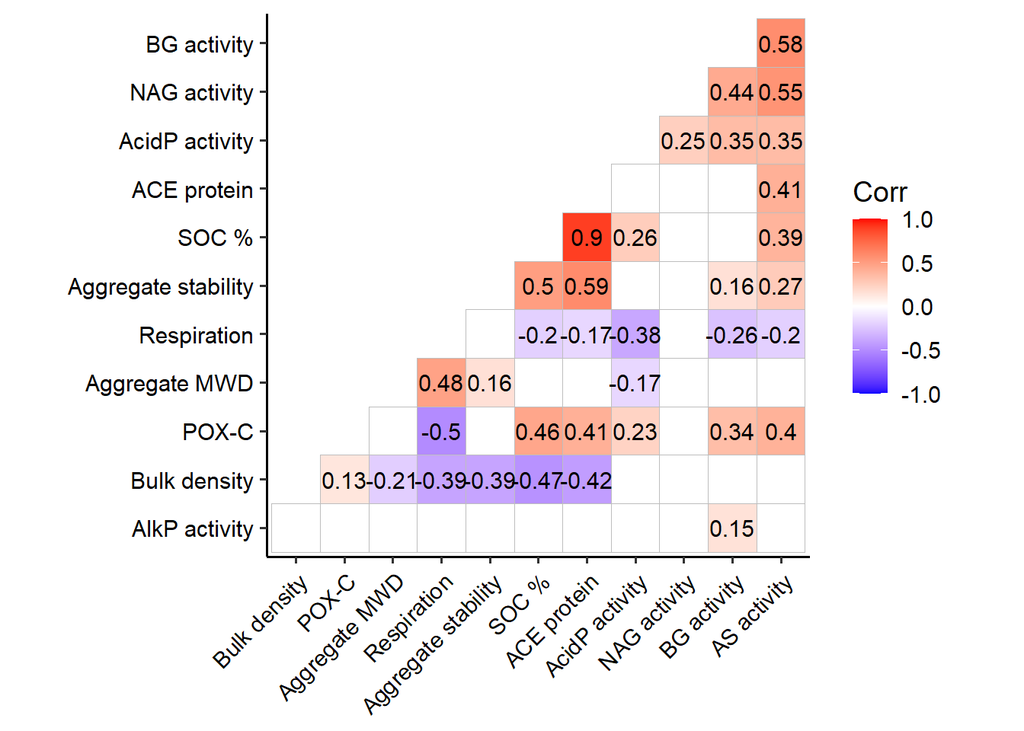

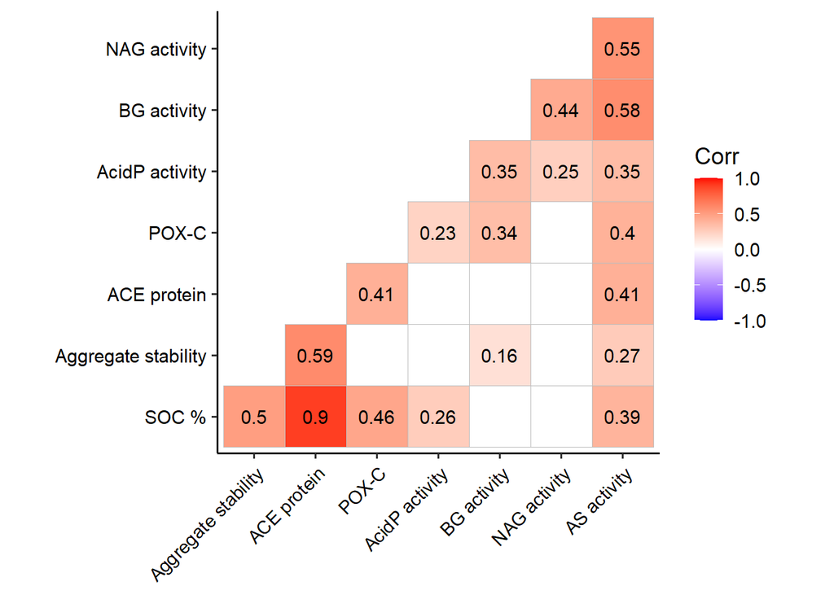

Takeaways from correlation plot:

- Besides TN%, ACE is the strongest covariate of SOC (correlation coefficient of 0.9).
- KSSL water-stable aggregates and POX-C are also decent covariates (correlation coefficients of 0.5 and 0.46, respectively)
- Arylsulfatase is the strongest enzyme covariate with SOC (0.39). Enzyme activities tend to be correlated with each other but not necessarily SOC%.

## Principal Components Analysis of indicator data

There are a lot of missing values in the indicator data because not every metric was measured by every cooperator. PCA doesn’t handle missing values, so I used the missMDA package to impute missing data. The package imputes missing values so that the imputed values have no weight on the results (i.e. just allows the analysis to be completed).

Impute missing data and run PCA of soil health indicators:

```r
nb <- estim_ncpPCA(indicators_only,method.cv = "Kfold", verbose = FALSE) # estimate the number of components from incomplete data
nb$ncp
```

```
## [1] 1
```

```r
res.comp <- imputePCA(indicators_only, ncp = nb$ncp)
imp_ind <- res.comp$completeObs
imp_pca <- prcomp(imp_ind, scale.=TRUE)
summary(imp_pca)
```

```
## Importance of components:
##                           PC1    PC2    PC3     PC4     PC5     PC6     PC7
## Standard deviation     1.9399 1.4365 1.2560 1.02154 0.97473 0.81153 0.74676
## Proportion of Variance 0.3136 0.1720 0.1315 0.08696 0.07918 0.05488 0.04647
## Cumulative Proportion  0.3136 0.4856 0.6170 0.70399 0.78316 0.83804 0.88451
##                            PC8     PC9   PC10    PC11    PC12
## Standard deviation     0.65779 0.59554 0.5444 0.47293 0.28007
## Proportion of Variance 0.03606 0.02956 0.0247 0.01864 0.00654
## Cumulative Proportion  0.92057 0.95013 0.9748 0.99346 1.00000
```

Plot PCA results:

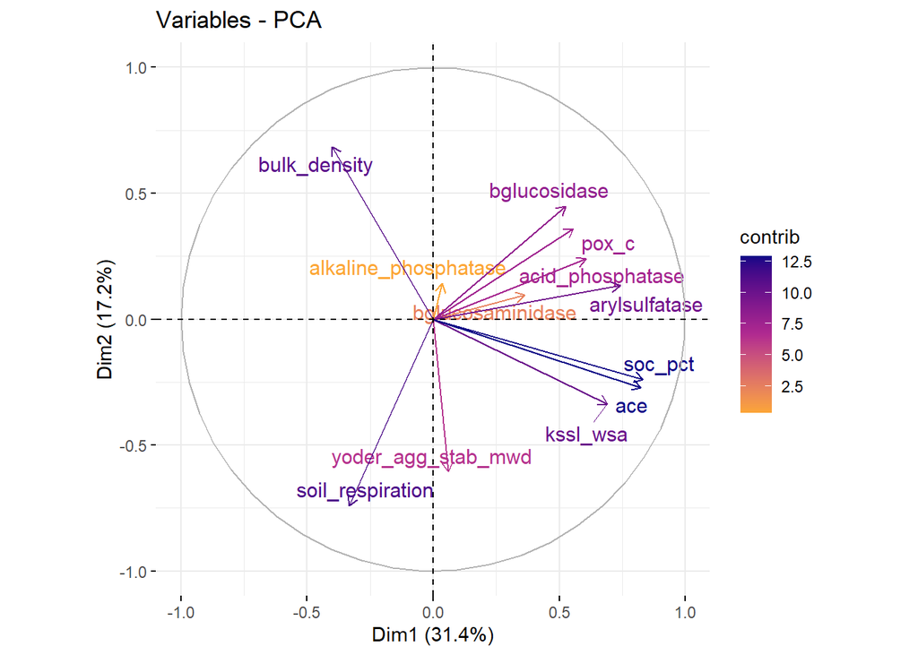

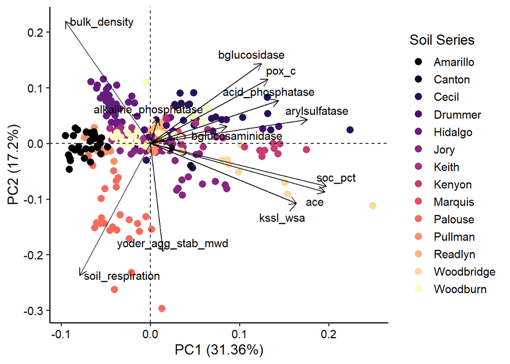

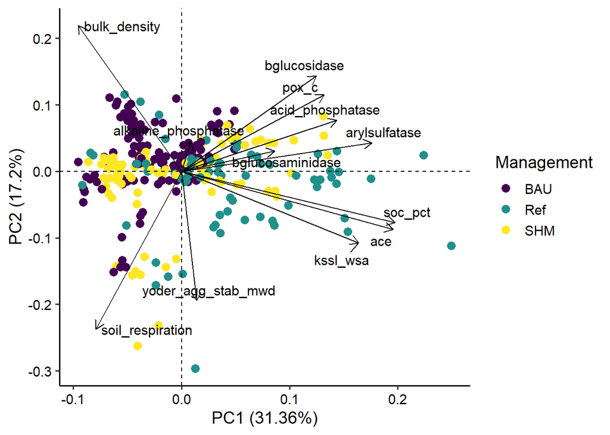

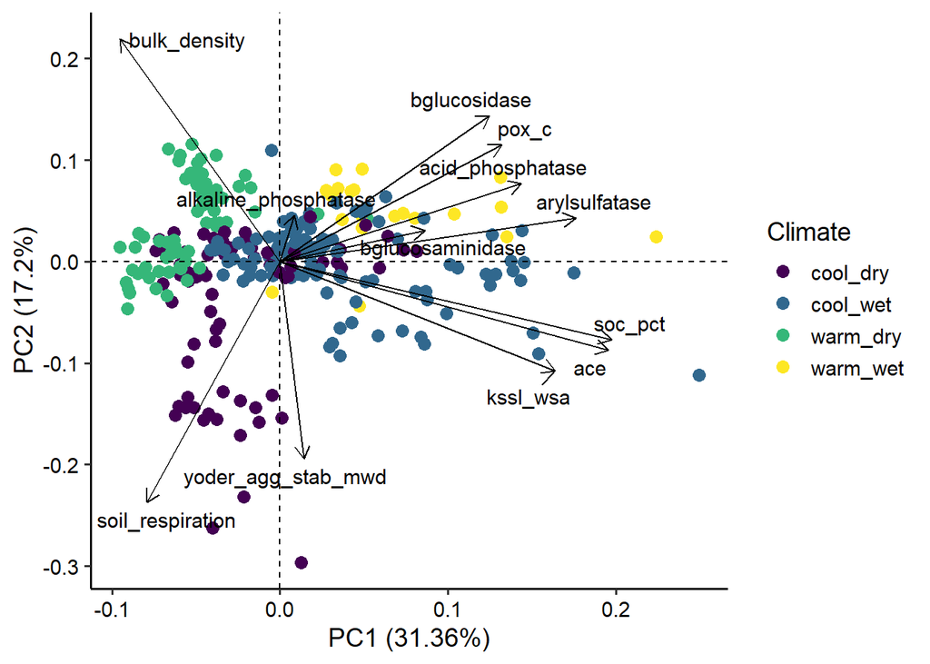

The loadings plot shows that some of the variables that strongly influenced the principal components are bulk density, soil respiration, SOC%, phosphodiesterase, and ACE. A few variables grouped together pretty closely: SOC%, ACE, TN, and KSSL WSA stand out as very close, and most of the enzyme activities are bunched pretty closely together which makes sense. These results are fairly consistent with what we see in the correlation plots, which makes sense. The difference between a correlation plot and a PCA is that the correlation plot is showing correlations between variables, and the PCA is showing correlations between individuals.

I would take this with a grain of salt because there are imputed variables - the loadings plot may be more reflective of which variables had the most real data.

The first PCA score plot (colored by soil series) shows that the data cluster fairly strongly by soil series. The second PCA score plot (colored by management) shows that the data do not cluster particularly strongly by management. Note - I had tried to show both these things at once by coloring data by soil series and using shape to denote different management, but I personally found it too busy to read on one figure.

This finding is really consistent with what we see by looking at just the SOC data - soils group much more strongly by soil series than by management groupings. This makes a lot of sense, of course. It is exciting to see that SOC% groups pretty closely with many other variables on the loading plot - many of the soil health metrics we’re looking at are likely to reflect something about a soil sample’s carbon content.

I also tried a PCA score plot colored by climate. This shows that data cluster fairly strongly by climate. However, I am hesitant to read too much into this, as many climates are represented by only one project. This may really be showing that data cluster strongly by project, which is to be expected (and consistent with analyses so far).

## Identify environmental covariates of indicators using glmulti and partial regressions

We can try to tease out some of the drivers of variability in indicator values across the dataset - this is helpful to understand if differences in indicator values are driven by soil, climate, land use, etc. Here, glmulti is used to identify the best-fit model for each indicator with environmental variables as predictors.

Make top model for each indicator into a nice table:

| indicator | model | adj.r.squared | p.value | AIC | nobs | sig |
| --- | --- | --- | --- | --- | --- | --- |
| soc_pct | value ~ 1 + mat + lu + clay_tot_psa | 0.775 | 0.000 | 261.567 | 124 | significant |
| bglucosidase | value ~ 1 + map + lu + clay_tot_psa | 0.712 | 0.000 | 1,689.669 | 148 | significant |
| kssl_wsa | value ~ 1 + mat + till + clay_tot_psa | 0.653 | 0.000 | 789.928 | 94 | significant |
| arylsulfatase | value ~ 1 + map + lu + clay_tot_psa | 0.639 | 0.000 | 1,716.819 | 139 | significant |
| ace | value ~ 1 + map + till + clay_tot_psa | 0.630 | 0.000 | 608.673 | 124 | significant |
| acid_phosphatase | value ~ 1 + map + lu + clay_tot_psa | 0.618 | 0.000 | 1,528.674 | 119 | significant |
| pox_c | value ~ 1 + map + lu + clay_tot_psa | 0.612 | 0.000 | 1,897.561 | 148 | significant |
| bulk_density | value ~ 1 + mat + map + clay_tot_psa | 0.421 | 0.000 | -23.760 | 141 | significant |
| alkaline_phosphatase | value ~ 1 + mat + map + clay_tot_psa | 0.347 | 0.000 | 1,987.422 | 148 | significant |
| soil_respiration | value ~ 1 + map + lu + clay_tot_psa | 0.297 | 0.000 | 1,478.915 | 124 | significant |
| yoder_agg_stab_mwd | value ~ 1 + mat + lu + clay_tot_psa | 0.258 | 0.000 | 967.824 | 147 | significant |
| bglucosaminidase | value ~ 1 + map + clay_tot_psa | 0.020 | 0.086 | 1,902.537 | 148 | not significant |

Pull out the partial R<sup>2</sup> values for all models:

| indicator | model | adj.r.squared | var | partial_r2 |
| --- | --- | --- | --- | --- |
| soc_pct | value ~ 1 + mat + lu + clay_tot_psa | 0.78 | mat | 0.41 |
| soc_pct | value ~ 1 + mat + lu + clay_tot_psa | 0.78 | luFORAGE | 0.25 |
| soc_pct | value ~ 1 + mat + lu + clay_tot_psa | 0.78 | luFOREST | 0.04 |
| soc_pct | value ~ 1 + mat + lu + clay_tot_psa | 0.78 | luGRASS | 0.00 |
| soc_pct | value ~ 1 + mat + lu + clay_tot_psa | 0.78 | luRANGE | 0.34 |
| soc_pct | value ~ 1 + mat + lu + clay_tot_psa | 0.78 | clay_tot_psa | 0.12 |
| bglucosidase | value ~ 1 + map + lu + clay_tot_psa | 0.71 | map | 0.65 |
| bglucosidase | value ~ 1 + map + lu + clay_tot_psa | 0.71 | luFORAGE | 0.02 |
| bglucosidase | value ~ 1 + map + lu + clay_tot_psa | 0.71 | luFOREST | 0.02 |
| bglucosidase | value ~ 1 + map + lu + clay_tot_psa | 0.71 | luGRASS | 0.01 |
| bglucosidase | value ~ 1 + map + lu + clay_tot_psa | 0.71 | luRANGE | 0.15 |
| bglucosidase | value ~ 1 + map + lu + clay_tot_psa | 0.71 | clay_tot_psa | 0.10 |
| kssl_wsa | value ~ 1 + mat + till + clay_tot_psa | 0.65 | mat | 0.17 |
| kssl_wsa | value ~ 1 + mat + till + clay_tot_psa | 0.65 | tillPerennial | 0.43 |
| kssl_wsa | value ~ 1 + mat + till + clay_tot_psa | 0.65 | tillTill | 0.04 |
| kssl_wsa | value ~ 1 + mat + till + clay_tot_psa | 0.65 | clay_tot_psa | 0.01 |
| arylsulfatase | value ~ 1 + map + lu + clay_tot_psa | 0.64 | map | 0.49 |
| arylsulfatase | value ~ 1 + map + lu + clay_tot_psa | 0.64 | luFORAGE | 0.10 |
| arylsulfatase | value ~ 1 + map + lu + clay_tot_psa | 0.64 | luFOREST | 0.00 |
| arylsulfatase | value ~ 1 + map + lu + clay_tot_psa | 0.64 | luGRASS | 0.00 |
| arylsulfatase | value ~ 1 + map + lu + clay_tot_psa | 0.64 | luRANGE | 0.23 |
| arylsulfatase | value ~ 1 + map + lu + clay_tot_psa | 0.64 | clay_tot_psa | 0.00 |
| ace | value ~ 1 + map + till + clay_tot_psa | 0.63 | map | 0.31 |
| ace | value ~ 1 + map + till + clay_tot_psa | 0.63 | tillPerennial | 0.14 |
| ace | value ~ 1 + map + till + clay_tot_psa | 0.63 | tillTill | 0.04 |
| ace | value ~ 1 + map + till + clay_tot_psa | 0.63 | clay_tot_psa | 0.14 |
| acid_phosphatase | value ~ 1 + map + lu + clay_tot_psa | 0.62 | map | 0.14 |
| acid_phosphatase | value ~ 1 + map + lu + clay_tot_psa | 0.62 | luFORAGE | 0.02 |
| acid_phosphatase | value ~ 1 + map + lu + clay_tot_psa | 0.62 | luFOREST | 0.02 |
| acid_phosphatase | value ~ 1 + map + lu + clay_tot_psa | 0.62 | luGRASS | 0.01 |
| acid_phosphatase | value ~ 1 + map + lu + clay_tot_psa | 0.62 | luRANGE | 0.58 |
| acid_phosphatase | value ~ 1 + map + lu + clay_tot_psa | 0.62 | clay_tot_psa | 0.04 |
| pox_c | value ~ 1 + map + lu + clay_tot_psa | 0.61 | map | 0.30 |
| pox_c | value ~ 1 + map + lu + clay_tot_psa | 0.61 | luFORAGE | 0.27 |
| pox_c | value ~ 1 + map + lu + clay_tot_psa | 0.61 | luFOREST | 0.02 |
| pox_c | value ~ 1 + map + lu + clay_tot_psa | 0.61 | luGRASS | 0.02 |
| pox_c | value ~ 1 + map + lu + clay_tot_psa | 0.61 | luRANGE | 0.11 |
| pox_c | value ~ 1 + map + lu + clay_tot_psa | 0.61 | clay_tot_psa | 0.22 |
| bulk_density | value ~ 1 + mat + map + clay_tot_psa | 0.42 | mat | 0.40 |
| bulk_density | value ~ 1 + mat + map + clay_tot_psa | 0.42 | map | 0.12 |
| bulk_density | value ~ 1 + mat + map + clay_tot_psa | 0.42 | clay_tot_psa | 0.02 |
| alkaline_phosphatase | value ~ 1 + mat + map + clay_tot_psa | 0.35 | mat | 0.06 |
| alkaline_phosphatase | value ~ 1 + mat + map + clay_tot_psa | 0.35 | map | 0.33 |
| alkaline_phosphatase | value ~ 1 + mat + map + clay_tot_psa | 0.35 | clay_tot_psa | 0.08 |
| soil_respiration | value ~ 1 + map + lu + clay_tot_psa | 0.30 | map | 0.20 |
| soil_respiration | value ~ 1 + map + lu + clay_tot_psa | 0.30 | luFORAGE | 0.02 |
| soil_respiration | value ~ 1 + map + lu + clay_tot_psa | 0.30 | luFOREST | 0.01 |
| soil_respiration | value ~ 1 + map + lu + clay_tot_psa | 0.30 | luGRASS | 0.02 |
| soil_respiration | value ~ 1 + map + lu + clay_tot_psa | 0.30 | luRANGE | 0.12 |
| soil_respiration | value ~ 1 + map + lu + clay_tot_psa | 0.30 | clay_tot_psa | 0.06 |
| yoder_agg_stab_mwd | value ~ 1 + mat + lu + clay_tot_psa | 0.26 | mat | 0.05 |
| yoder_agg_stab_mwd | value ~ 1 + mat + lu + clay_tot_psa | 0.26 | luFORAGE | 0.00 |
| yoder_agg_stab_mwd | value ~ 1 + mat + lu + clay_tot_psa | 0.26 | luFOREST | 0.16 |
| yoder_agg_stab_mwd | value ~ 1 + mat + lu + clay_tot_psa | 0.26 | luGRASS | 0.13 |
| yoder_agg_stab_mwd | value ~ 1 + mat + lu + clay_tot_psa | 0.26 | luRANGE | 0.01 |
| yoder_agg_stab_mwd | value ~ 1 + mat + lu + clay_tot_psa | 0.26 | clay_tot_psa | 0.00 |
| bglucosaminidase | value ~ 1 + map + clay_tot_psa | 0.02 | map | 0.03 |
| bglucosaminidase | value ~ 1 + map + clay_tot_psa | 0.02 | clay_tot_psa | 0.00 |

Plot the partial R<sup>2</sup> for significant predictors of each indicator:

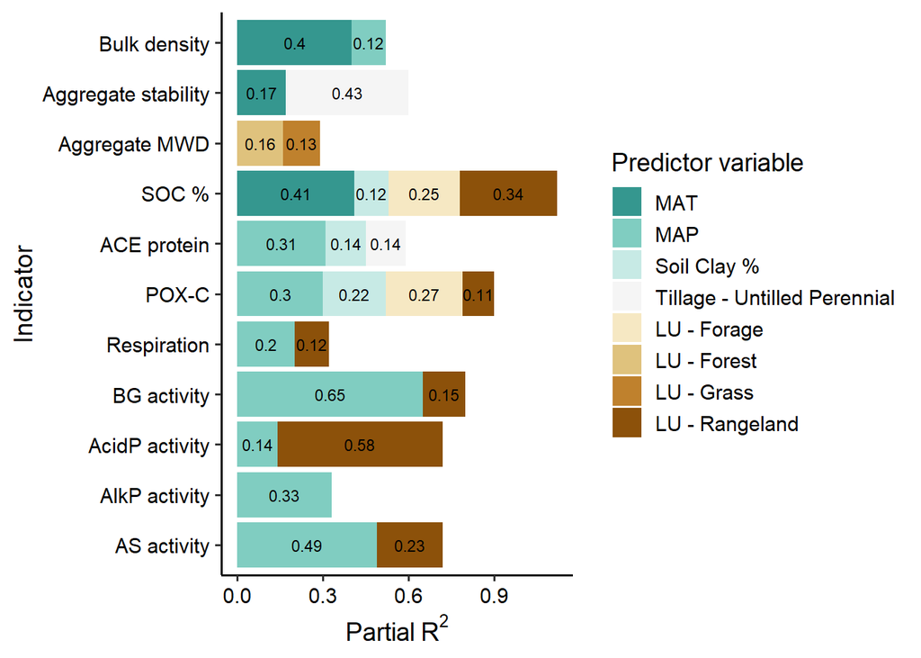

Takeaways:

- SOC% is the most strongly predicted by environmental and land use covariates
- Adjusted R<sup>2</sup> for the best model was 0.77, and the predictors were MAT, land use, and soil clay %
  - The strongest individual covariates were MAT (partial R<sup>2</sup>=0.41) and rangeland land use (partial R<sup>2</sup>=0.34)
- B-glucosidase was most strongly influenced by MAP (partial R<sup>2</sup>=0.65)
- KSSL aggregate stability was the indicator most strongly influenced by tillage (partial R<sup>2</sup>=0.43)
- Acid phosphatase strongly influenced by rangeland land use
- Indicators the least well-predicted by covariates (best models had adjusted R<sup>2</sup><0.5): bulk density, alkaline phosphatase, respiration, Yoder aggregate stability, phosphodiesterase, bglucosaminidase (NAG)

## Environmental covariates of indicators in reference sites only

Select best model predicting each indicator at reference sites only using glmulti.

Make top model for each indicator into a nice table:

| indicator | model | adj.r.squared | p.value | AIC | nobs | sig |
| --- | --- | --- | --- | --- | --- | --- |
| arylsulfatase | value ~ 1 + map + lu + clay_tot_psa | 0.955 | 0.000 | 291.120 | 27 | significant |
| soc_pct | value ~ 1 + map + lu + clay_tot_psa | 0.936 | 0.000 | 40.164 | 24 | significant |
| bglucosidase | value ~ 1 + lu + clay_tot_psa | 0.902 | 0.000 | 294.269 | 30 | significant |
| bglucosaminidase | value ~ 1 + map + lu + clay_tot_psa | 0.892 | 0.000 | 267.982 | 30 | significant |
| bulk_density | value ~ 1 + mat + map + clay_tot_psa | 0.876 | 0.000 | -48.675 | 30 | significant |
| pox_c | value ~ 1 + mat + lu + clay_tot_psa | 0.873 | 0.000 | 355.536 | 30 | significant |
| ace | value ~ 1 + mat + map + clay_tot_psa | 0.840 | 0.000 | 113.095 | 24 | significant |
| soil_respiration | value ~ 1 + mat + lu + clay_tot_psa | 0.735 | 0.000 | 262.050 | 24 | significant |
| acid_phosphatase | value ~ 1 + lu + clay_tot_psa | 0.662 | 0.000 | 381.236 | 28 | significant |
| alkaline_phosphatase | value ~ 1 + map + lu + clay_tot_psa | 0.631 | 0.000 | 344.904 | 30 | significant |
| yoder_agg_stab_mwd | value ~ 1 + mat + lu + clay_tot_psa | 0.599 | 0.000 | 205.753 | 30 | significant |
| kssl_wsa | value ~ 1 + mat + clay_tot_psa | 0.168 | 0.068 | 193.437 | 22 | not significant |

Pull out the partial R<sup>2</sup> values for all models:

| indicator | model | adj.r.squared | var | partial_r2 |
| --- | --- | --- | --- | --- |
| arylsulfatase | value ~ 1 + map + lu + clay_tot_psa | 0.96 | map | 0.93 |
| arylsulfatase | value ~ 1 + map + lu + clay_tot_psa | 0.96 | luFOREST | 0.62 |
| arylsulfatase | value ~ 1 + map + lu + clay_tot_psa | 0.96 | luGRASS | 0.00 |
| arylsulfatase | value ~ 1 + map + lu + clay_tot_psa | 0.96 | luRANGE | 0.02 |
| arylsulfatase | value ~ 1 + map + lu + clay_tot_psa | 0.96 | clay_tot_psa | 0.01 |
| soc_pct | value ~ 1 + map + lu + clay_tot_psa | 0.94 | map | 0.91 |
| soc_pct | value ~ 1 + map + lu + clay_tot_psa | 0.94 | luGRASS | 0.77 |
| soc_pct | value ~ 1 + map + lu + clay_tot_psa | 0.94 | luRANGE | 0.76 |
| soc_pct | value ~ 1 + map + lu + clay_tot_psa | 0.94 | clay_tot_psa | 0.29 |
| bglucosidase | value ~ 1 + lu + clay_tot_psa | 0.90 | luFOREST | 0.60 |
| bglucosidase | value ~ 1 + lu + clay_tot_psa | 0.90 | luGRASS | 0.01 |
| bglucosidase | value ~ 1 + lu + clay_tot_psa | 0.90 | luRANGE | 0.87 |
| bglucosidase | value ~ 1 + lu + clay_tot_psa | 0.90 | clay_tot_psa | 0.05 |
| bglucosaminidase | value ~ 1 + map + lu + clay_tot_psa | 0.89 | map | 0.78 |
| bglucosaminidase | value ~ 1 + map + lu + clay_tot_psa | 0.89 | luFOREST | 0.66 |
| bglucosaminidase | value ~ 1 + map + lu + clay_tot_psa | 0.89 | luGRASS | 0.01 |
| bglucosaminidase | value ~ 1 + map + lu + clay_tot_psa | 0.89 | luRANGE | 0.87 |
| bglucosaminidase | value ~ 1 + map + lu + clay_tot_psa | 0.89 | clay_tot_psa | 0.04 |
| bulk_density | value ~ 1 + mat + map + clay_tot_psa | 0.88 | mat | 0.80 |
| bulk_density | value ~ 1 + mat + map + clay_tot_psa | 0.88 | map | 0.34 |
| bulk_density | value ~ 1 + mat + map + clay_tot_psa | 0.88 | clay_tot_psa | 0.35 |
| pox_c | value ~ 1 + mat + lu + clay_tot_psa | 0.87 | mat | 0.74 |
| pox_c | value ~ 1 + mat + lu + clay_tot_psa | 0.87 | luFOREST | 0.16 |
| pox_c | value ~ 1 + mat + lu + clay_tot_psa | 0.87 | luGRASS | 0.83 |
| pox_c | value ~ 1 + mat + lu + clay_tot_psa | 0.87 | luRANGE | 0.85 |
| pox_c | value ~ 1 + mat + lu + clay_tot_psa | 0.87 | clay_tot_psa | 0.06 |
| ace | value ~ 1 + mat + map + clay_tot_psa | 0.84 | mat | 0.59 |
| ace | value ~ 1 + mat + map + clay_tot_psa | 0.84 | map | 0.57 |
| ace | value ~ 1 + mat + map + clay_tot_psa | 0.84 | clay_tot_psa | 0.15 |
| soil_respiration | value ~ 1 + mat + lu + clay_tot_psa | 0.74 | mat | 0.35 |
| soil_respiration | value ~ 1 + mat + lu + clay_tot_psa | 0.74 | luGRASS | 0.16 |
| soil_respiration | value ~ 1 + mat + lu + clay_tot_psa | 0.74 | luRANGE | 0.15 |
| soil_respiration | value ~ 1 + mat + lu + clay_tot_psa | 0.74 | clay_tot_psa | 0.02 |
| acid_phosphatase | value ~ 1 + lu + clay_tot_psa | 0.66 | luFOREST | 0.00 |
| acid_phosphatase | value ~ 1 + lu + clay_tot_psa | 0.66 | luGRASS | 0.00 |
| acid_phosphatase | value ~ 1 + lu + clay_tot_psa | 0.66 | luRANGE | 0.63 |
| acid_phosphatase | value ~ 1 + lu + clay_tot_psa | 0.66 | clay_tot_psa | 0.00 |
| alkaline_phosphatase | value ~ 1 + map + lu + clay_tot_psa | 0.63 | map | 0.07 |
| alkaline_phosphatase | value ~ 1 + map + lu + clay_tot_psa | 0.63 | luFOREST | 0.05 |
| alkaline_phosphatase | value ~ 1 + map + lu + clay_tot_psa | 0.63 | luGRASS | 0.12 |
| alkaline_phosphatase | value ~ 1 + map + lu + clay_tot_psa | 0.63 | luRANGE | 0.34 |
| alkaline_phosphatase | value ~ 1 + map + lu + clay_tot_psa | 0.63 | clay_tot_psa | 0.07 |
| yoder_agg_stab_mwd | value ~ 1 + mat + lu + clay_tot_psa | 0.60 | mat | 0.26 |
| yoder_agg_stab_mwd | value ~ 1 + mat + lu + clay_tot_psa | 0.60 | luFOREST | 0.42 |
| yoder_agg_stab_mwd | value ~ 1 + mat + lu + clay_tot_psa | 0.60 | luGRASS | 0.17 |
| yoder_agg_stab_mwd | value ~ 1 + mat + lu + clay_tot_psa | 0.60 | luRANGE | 0.11 |
| yoder_agg_stab_mwd | value ~ 1 + mat + lu + clay_tot_psa | 0.60 | clay_tot_psa | 0.01 |
| kssl_wsa | value ~ 1 + mat + clay_tot_psa | 0.17 | mat | 0.23 |
| kssl_wsa | value ~ 1 + mat + clay_tot_psa | 0.17 | clay_tot_psa | 0.14 |

Plot partial R<sup>2</sup> of significant predictors in reference sites:

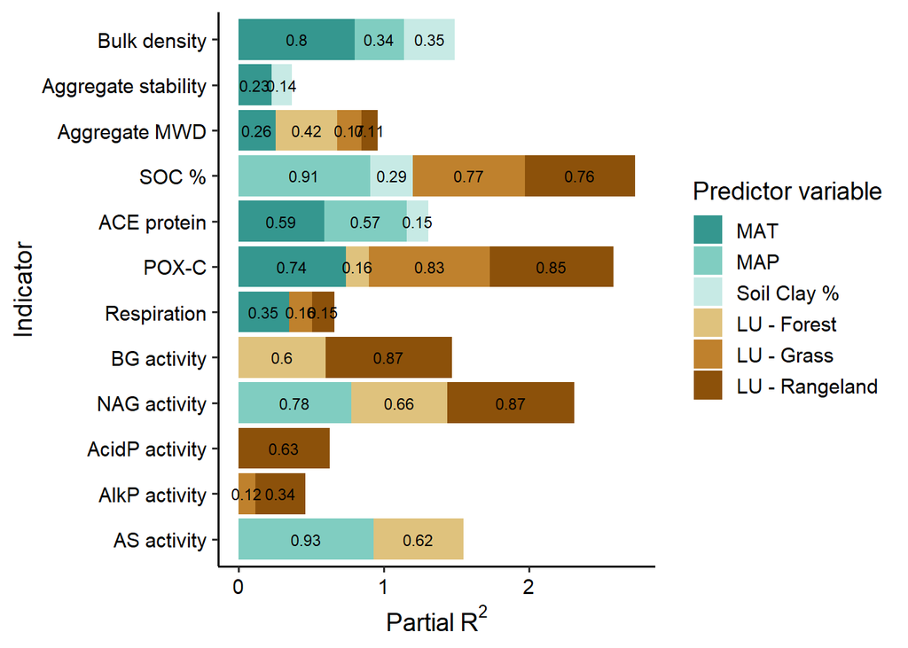

Takeaways:

- Arylsulfatase was the best predicted by environmental covariates (adjusted R<sup>2</sup>=0.955), followed by SOC (adjusted R<sup>2</sup>=0.936)
  - top model for both included MAP, land use, and soil clay content
- Significant models with R<sup>2</sup>>0.5 determined for all indicators except for KSSL WSA
- Climate variable (MAT, MAP, or both) was a predictor in most models
- Land use also often a strong indicator
- Soil clay content tended to be the least important predictor variable based on partial regression analysis, except for phosphodiesterase and bulk density

# Use meta-analysis methods to determine indicator sensitivity to management across all projects

We’re going to treat the DSP4SH database like a meta-analysis and use functions in the metafor() package to calculate the effect size of SHM and Ref treatments on soil health indicators. This version of the analysis uses data that is slightly altered from what cooperators originally provided - the names of some treatments have been changed to combine treatments that are reasonably similar for accurate effect size calculation.

Changes:

- Kansas State Ref “Native Rangeland” treatments were combined into one
- NC State BAU (Wheat 1-3) and SHM (Hay 1-3) were recoded as just “wheat” and “hay” so each replicate wouldn’t be treated as a treatment
- All Oregon State no-till grass projects were coded to land use = “GRASS” (previously, two were coded as “CROP” and one was coded as “GRASS” leading to separation of these treatments)
- Texas A&M BAU and SHM treatment labels were condensed
- Washington State labels were condensed

## Calculate effect size for individual treatments and plot indicator effect sizes

Prep data for effect size calculation:

```r
# Pivot data longer
meta_long <- meta_df_alt %>%
  select(project, dsp_pedon_id, soil, label, climate, lu, till, trt, soc_stock_0_30cm, soc_stock_100cm,
         soc_pct, bulk_density, kssl_wsa:yoder_agg_stab_mwd, soil_respiration:acid_phosphatase, arylsulfatase:ace) %>%
  pivot_longer(soc_stock_0_30cm:ace, names_to="indicator", values_to="value")

# Make a new treatment variable with two values, BAU and ASP. ASP will contain all of the SHM and Ref soils.
meta_long2 <- meta_long %>%
  mutate(treat = ifelse(label=="BAU", "BAU", "ASP"))

# Calculate mean, sd, and n for BAU soils - need this for effect size calculation input
bau_means <- meta_long2 %>%
  filter(treat=="BAU") %>%
  filter(dsp_pedon_id!="BAU9-1") %>% # exclude pedon BAU9-1 from analysis - it's from WashingtonState study and has implausibly high enzyme activity
  group_by(project, indicator) %>%
  nest() %>%
  mutate(
    mean_bau = map_dbl(data, ~mean(.$value, na.rm = TRUE)),
    sd_bau = map_dbl(data, ~sd(.$value, na.rm = TRUE)),
    n_bau = map_dbl(data, ~sum(!is.na(.$value)))) %>%
  select(indicator, project, mean_bau, sd_bau, n_bau) %>%
  ungroup()

# Calculate mean, sd, and n for Ref and SHM
nested2 <- meta_long2 %>%
  filter(treat=="ASP") %>%
  group_by(indicator, label, project, lu, till, trt) %>%
  nest() %>%
  mutate(
    mean_asp = map_dbl(data, ~mean(.$value, na.rm = TRUE)),
    sd_asp = map_dbl(data, ~sd(.$value, na.rm = TRUE)),
    n_asp = map_dbl(data, ~sum(!is.na(.$value)))) %>%
  select(indicator, label, project, lu, till, trt, mean_asp, sd_asp, n_asp) %>%
  ungroup()

# Put data together. This will be input for escalc() function to calculate effect sizes
es_in_big <- nested2 %>%
  left_join(bau_means, by=c("indicator", "project")) %>%
  na.omit()
flextable(es_in_big)
```

Calculate effect sizes:

```r
es_asp1 <- escalc(n1i = n_asp, n2i = n_bau, m1i = mean_asp, m2i = mean_bau,
                  sd1i = sd_asp, sd2i = sd_bau, data = es_in_big, measure = "ROM")

# Average climate data - to be added in to project overview table
site_clim_sum <- project %>%
  group_by(project) %>%
  summarize(across(mat:map, ~ mean(.x, na.rm = TRUE))) %>%
  mutate(mat = round(mat, 1),
         map = round(map, 0))

# Calculate site mean clay%
site_clay <- meta_df_alt %>%
  group_by(project, label) %>%
  summarize(clay_mean = mean(clay_tot_psa, na.rm=TRUE))
# Join climate and clay% data to effect size data - these will be used as moderator variables for meta-regression later on
es_asp <- es_asp1 %>%
  na.omit() %>% # omit any rows with NA - this should just be places where NaNs were calculated
  unite("proj_trt", project, trt, remove = FALSE) %>%
  rename(till_orig = till) %>%
  mutate(till = ifelse(till_orig == "Till", "No-till", till_orig)) %>% # fix Texas A&M data that was mislabeled - no-till treatment was coded as Till
  relocate(till, .before=till_orig) %>%
  left_join(site_clim_sum, by="project") %>% # add in climate data
  left_join(site_clay, by=c("project", "label")) # add in clay content
```

Once effect sizes are calculated, they can be used to calculate a random effects model to determine significance of effect sizes.

```r
# nest data by indicators and treatment contrasts, calculate random-effects models, extract data from model
es_asp_rma_nomod <- es_asp %>%
  group_by(indicator, label) %>%
  nest() %>%
  mutate(rma_obj = map(data, ~rma(yi, vi, slab = proj_trt, data=.x, method="REML"))) %>%
  mutate(rma_tidy = map(rma_obj, broom::tidy)) %>%
  # make dataframe with effect sizes and variances for individual studies
  mutate(study_df = map(rma_obj, ~data.frame(es = .x$yi,
                                             se= sqrt(.x$vi),
                                             type = "study",
                                             study=.x$slab))) %>%
  # make dataframe with overall random effects model estimate and standard error
  mutate(summary_df = map(rma_obj, ~data.frame(es = .x$b,
                                               se=.x$se,
                                               type= "summary",
                                               study="summary"))) %>%
  # put two dfs together into one that can be used to make a forest plot
  mutate(plot_df = map2(study_df, summary_df, rbind))
```

Generate forest plots for each indicator, and a table of which indicators are significantly influenced by treatment:

[output not shown]

[output cut: 28 more lines]

[output not shown]

Observations from forest plots:

- ACE is positive in almost every Ref case, more variable in SHM but still trends positive
- Many enzymes tend to be positive in most Ref cases, but response is inconsistent in SHM conditions
- Bulk density is negative in Ref cases (meaning less compaction, which makes sense), and is not different between BAU and SHM cases
- KSSL WSA are almost always positive
- Both POX-C and SOC are fairly positive in Ref cases, but unchanged in SHM
- Soil respiration is all over the place
- Yoder MWD tends to be positive in Ref cases, but inconsistent in SHM